# comp_chem_projects

## Project 1: Quantum and classical harmonic oscillators

### 1-1

Potential energy surface: $$ U(x) = \frac{1}{2}kx^2 $$

The dimensionless Hamiltonian for a single particle undergoing this potential: $$ H = -\frac{1}{2}\frac{d^2}{dx^2} + \frac{1}{2}x^2 $$

where the dimensionless length (x) relates to the original length u as: $u= x\sqrt{\frac{\hbar}{m\omega}}$

Therefore the dimensionless energy we calculate (E) will relate to the original energy ($\epsilon$) as: $E = \frac{\epsilon}{\hbar\omega}$

### 1-2 QHO

Gaussian basis functions: $$ \phi_A(x) = \exp( - \alpha (x-x_A)^2) $$

Gaussian basis set: $$ \psi(x) = \sum_\mu c_\mu\phi_\mu $$

SE in basis set: $$ \hat{H} \sum_\mu c_\mu \phi_\mu (x) = E \sum_\mu c_\mu \phi_\mu (x) $$

Left multiply by the bra of another basis function:

$$ \sum_\mu \langle\phi_\nu| H |\phi_\mu\rangle c_\mu = E \sum_\mu \langle\phi_\nu| \phi_\mu\rangle c_\mu $$

$H_{\nu\mu}$: $\langle\phi_\nu| H |\phi_\mu\rangle$

$S_{\nu\mu}$: $\langle\phi_\nu| \phi_\mu\rangle$

$$ \sum_\mu H_{\nu\mu} c_\mu = E \sum_\mu S_{\nu\mu} c_\mu $$

Matrix representation:

$$ H c = E S c $$$$ (S^{-1}H) c = E c $$$$ cSc = 1 $$

$H_{AB}$: $\langle\phi_A| H |\phi_B\rangle$ and $S_{AB}$: $\langle\phi_A| \phi_B\rangle$

$$ H_{AB} = \int dx \exp\left( - \alpha (x-x_A)^2\right) \left(-\frac{d^2}{dx^2} + \frac{1}{2} x^2\right) \exp \left( - \alpha (x-x_B)^2 \right) $$$$ S_{AB} = \int dx \exp\left( - \alpha (x-x_A)^2\right) \exp \left( - \alpha (x-x_B)^2 \right) $$$$ S_{AB} = \sqrt{\dfrac{\pi}{2\alpha}} \exp \left( - \dfrac{\alpha}{2} (x_A-x_B)^2 \right) $$$$ H_{AB} = \dfrac{1}{2}S_{AB} \left[ \alpha - \alpha^2(x_A-x_B)^2 + \dfrac{1}{4}(\dfrac{1}{2} + (x_A+x_B)^2) \right] $$

```
Eigenvalues:
i = 0, eigval = 0.500000
i = 1, eigval = 1.500000
i = 2, eigval = 2.500000

Eigenvectors:
i = 0, eigvec = [-8.66948543e-06 -4.50136853e-05 -3.05584932e-04 -1.48050962e-03
 -5.95648303e-03 -1.92267422e-02 -5.02395583e-02 -1.05981867e-01
 -1.80675313e-01 -2.48797444e-01 -2.76816540e-01 -2.48797444e-01
 -1.80675313e-01 -1.05981867e-01 -5.02395583e-02 -1.92267422e-02
 -5.95648301e-03 -1.48050963e-03 -3.05584924e-04 -4.50136906e-05
 -8.66948362e-06]
i = 1, eigvec = [ 6.67581205e-05  3.01010862e-04  1.85256977e-03  7.80421507e-03
  2.69709680e-02  7.24927635e-02  1.51587109e-01  2.39797068e-01
  2.72556691e-01  1.87650104e-01 -1.30972386e-11 -1.87650104e-01
 -2.72556691e-01 -2.39797068e-01 -1.51587109e-01 -7.24927635e-02
 -2.69709681e-02 -7.80421504e-03 -1.85256980e-03 -3.01010853e-04
 -6.67581230e-05]
i = 2, eigvec = [ 0.00035803  0.00134893  0.00763186  0.02725301  0.0794732   0.17042812
  0.26443739  0.25849122  0.07809849 -0.19343892 -0.32592008 -0.19343892
  0.07809849  0.25849122  0.26443738  0.17042812  0.0794732   0.02725301
  0.00763186  0.00134893  0.00035803]
```

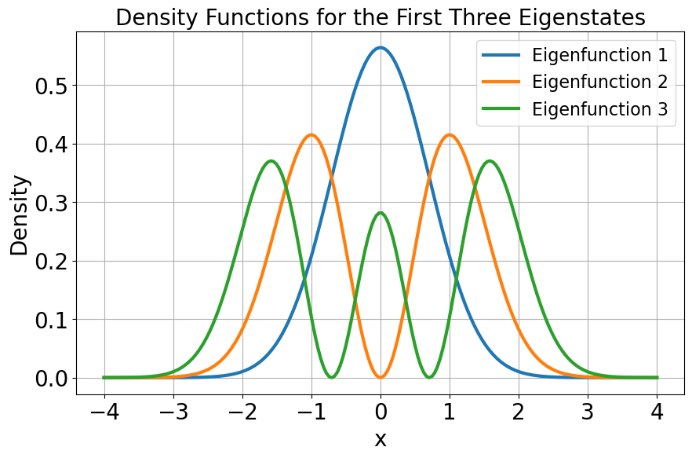

```
Average energy of the QHO at different temperatures using the Bose-Einstein distribution:
Average energy at T=0: 0.500000
Average energy at T=0.05: 0.500000
Average energy at T=0.1: 0.500045
Average energy at T=0.2: 0.506784
Average energy at T=0.5: 0.656518
Average energy at T=1: 1.081937
Average energy at T=2: 2.032948
Average energy at T=5: 4.541251
```

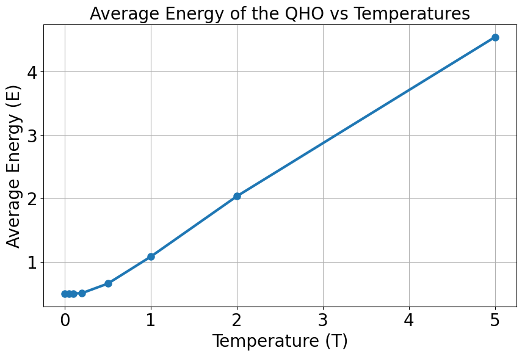

```python
# 1-2 Density functions of the 1D QHO

import numpy as np
import matplotlib.pyplot as plt

def phi_A_func(x_space, A, alpha=2.):
    return np.exp(-alpha*(x_space - A) ** 2.)

def S_AB_func(xA, xB, alpha):
    return (0.5*np.pi/alpha)**0.5 * np.exp(-0.5*alpha* (xA - xB)**2 )

def H_AB_func(xA, xB, alpha):
    return 0.5* S_AB_func(xA, xB, alpha) * (alpha - alpha**2 * (xA - xB)**2 + \
                             0.25*(1/alpha + (xA + xB)**2 ))

def S_H_AB_func(xA, xB, alpha):
    S_AB =  S_AB_func(xA, xB, alpha)
    H_AB = 0.5* S_AB * (alpha - alpha**2 * (xA - xB)**2 + \
                             0.25*(1/alpha + (xA + xB)**2 ))
    return S_AB, H_AB

def find_eigval_eigvec(S_AB, H_AB):
    # compute S^{-1}H
    S_inv_H = np.linalg.inv(S_AB) @ H_AB
    # eigval[i]  -> eigenvectors[:,i]
    eigval, eigvec = np.linalg.eig(S_inv_H)

    index_sort = np.argsort(eigval)
    eigval_sorted = eigval[index_sort]
    eigvec_sorted = eigvec[:, index_sort]

    for i in range(len(eigvec_sorted)):
        eigvec_sorted[:,i] /= np.sqrt(eigvec_sorted[:,i] @ S_AB @ eigvec_sorted[:,i])

    return eigval_sorted, eigvec_sorted

n_basis = 21
alpha = 2
gaussian_centers = np.linspace(-4, 4, n_basis)

S_AB, H_AB = S_H_AB_func(gaussian_centers[:,None], gaussian_centers[None,:], alpha)
eigval, eigvec = find_eigval_eigvec(S_AB, H_AB)

print("Eigenvalues:")
for i in range(3):
    print(f"i = {i}, eigval = {eigval[i]:.6f}")
print("\nEigenvectors:")
for i in range(3):
    print(f"i = {i}, eigvec = {eigvec[:,i]}")

# Plot the first three density functions
x_space = np.linspace(-4, 4, 200)
plt.figure(figsize=(10, 6))
for i in range(3):
    psi = 0
    for idx, center in enumerate(gaussian_centers):
        # psi = phi_A_func(x_space, gaussian_centers) @ eigvec[:, i] (after broadcasting in phi_A_func)
        # density = psi**2 # coefficients are real
        # plt.plot(x_space, density, label=f"Eigenfunction {i+1}")
        psi += phi_A_func(x_space, center, 2) * eigvec[idx, i]
    density = psi**2
    plt.plot(x_space, density, label=f"Eigenfunction {i+1}")

plt.title("Density Functions for the First Three Eigenstates")
plt.xlabel("x")
plt.ylabel("Density")
plt.legend()
plt.grid()
plt.savefig("Final_1ii_QHO_Density_Functions.png")
plt.show()


# Bose-Einstein distribution (unitless)
temperatures = [0, 0.05, 0.1, 0.2, 0.5, 1, 2, 5]
print("\nAverage energy of the QHO at different temperatures using the Bose-Einstein distribution:")
for temp in temperatures:
    if temp == 0:
        QHO_avg_E = eigval[0]  # ground state only
    else:
        boltzmann_weights = np.exp(-eigval / temp)
        Z = np.sum(boltzmann_weights)
        QHO_avg_E = np.sum(eigval * boltzmann_weights) / Z
    print(f"Average energy at T={temp}: {QHO_avg_E:.6f}")
# Plot the average energy as a function of temperature
plt.figure(figsize=(10, 6))
plt.plot(temperatures, [eigval[0] if t == 0 else np.sum(eigval * np.exp(-eigval / t)) / np.sum(np.exp(-eigval / t)) for t in temperatures], marker='o')
plt.title("Average Energy of the QHO vs Temperatures")
plt.xlabel("Temperature (T)")
plt.ylabel("Average Energy (E)")
plt.grid()
plt.show()
```

### 1-3 MD for 1D Classical HO

Velocity Verlet Integration Scheme:

Update velocity by half a step:

$$ v_{i+1/2} = v_i + \frac{1}{2} \Delta t \cdot F(x_i) $$

Update position by a full step:

$$ x_{i+1} = x_i + \Delta t \cdot v_{i+1/2} $$

Compute new force:

$$ F(x_{i+1}) $$

Complete velocity update using the new force:

$$ v_{i+1} = v_{i+1/2} + \frac{1}{2} \Delta t \cdot F(x_{i+1}) $$

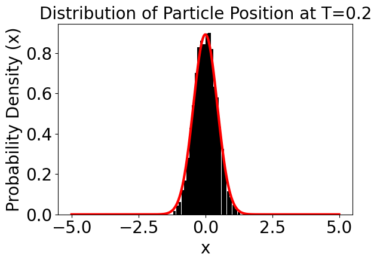

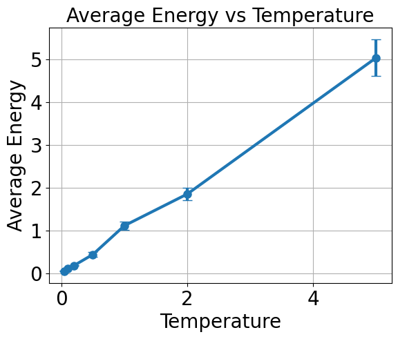

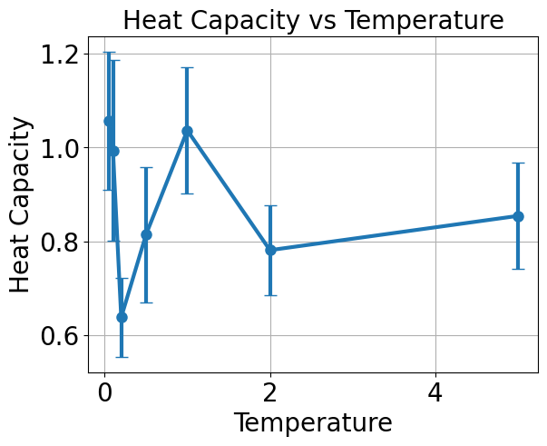

```
Average Energy and Heat Capacity with Errors:
Temperature(T) E_mean         E_mean_err     C_v            C_v_err
0.05           0.0486         0.0050         1.0571         0.1474
0.10           0.1119         0.0136         0.9935         0.1933
0.20           0.1783         0.0149         0.6374         0.0844
0.50           0.4371         0.0559         0.8139         0.1439
1.00           1.1090         0.0928         1.0366         0.1341
2.00           1.8495         0.1529         0.7809         0.0959
5.00           5.0343         0.4310         0.8540         0.1132
```

```python
# 1-3 MD via velocity Verlet integration with error bars and canonical comparison
import numpy as np
import matplotlib.pyplot as plt
from scipy.stats import sem  # Standard error of the mean

class histogram():
    def __init__(self, limits, binwidth):
        self.limits = limits
        self.binwidth = binwidth
        self.vals = np.arange(self.limits[0] + self.binwidth / 2, self.limits[1], self.binwidth)
        self.histo = 0 * self.vals
        self.N_samples = 0

    def add_sample(self,dat):
        self.N_samples += 1
        bin_index = int((dat - self.limits[0]) / self.binwidth)

        if bin_index < len(self.histo):
            #print(bin_index, dat, self.limits)
            self.histo[bin_index] += 1

    def normalize(self):
        self.histo = self.histo / (self.N_samples * self.binwidth)

    def barplot(self):
        plt.bar(self.vals, self.histo, width=0.95 * self.binwidth, color='k')

    def lineplot(self):
        plt.plot(self.vals, self.histo)

np.random.seed(18)

# Constants and parameters
mass = 1.0
omega = 1.0
k_B = 1.0
dt = 0.01
n_steps = 100000
temperatures = [0.05, 0.1, 0.2, 0.5, 1.0, 2.0, 5.0]
thermostat_interval = 500
burn_in_fraction = 0.1

# Potential and force
V = lambda x: 0.5 * mass * omega**2 * x**2
F = lambda x: -mass * omega**2 * x

def canonical_distribution(x_vals, T):
    Z = np.trapz(np.exp(-V(x_vals) / (k_B * T)), x_vals)
    return np.exp(-V(x_vals) / (k_B * T)) / Z

def verlet_step (x, v, dt, f_func):
    v = v + 0.5 * dt * f_func(x)  #velocity 1/2 timestep
    x = x + dt * v #position full timestep
    force = f_func(x) # new force
    v = v + 0.5 * dt * force #adjusted force for another 1/2 timestep of velocity
    return x, v

def anderson_thermostat(v, T, dt):
    if np.random.rand() < dt:
        v = np.random.normal(loc=0.0, scale=np.sqrt(k_B * T))
    return v

def initlialize (T):
    x, v =  0.0, np.random.normal(0, np.sqrt(T / mass))
    return x, v

# def heat_capacity(E_traj, T):
#     E_mean = np.mean(E_traj)
#     var_E = np.var(E_traj)
#     C_v = var_E / (k_B * T**2)
#     C_v_err = np.std((E_traj - E_mean)**2 / (k_B * T**2)) / np.sqrt(len(E_traj))
#     return C_v, C_v_err

def run_simulation(x, v, dt, f_func, T, n_steps, thermostat_interval):
    x_traj = np.zeros(n_steps)
    E_traj = np.zeros(n_steps)

    for step in range(n_steps):
        x, v = verlet_step(x, v, dt, f_func)

        #if (step % thermostat_interval == 0):
        v = anderson_thermostat(v, T, dt)

        x_traj[step] = x
        KE = 0.5 * mass * v**2
        PE = V(x)
        E_traj[step] = KE + PE
    return x_traj, E_traj

def compute_normalized_acf(data):
    y = np.array(data, dtype=float)
    y -= np.mean(y)
    N = len(y)
    padded = np.fft.fft(y, n=2*N)
    result = np.fft.ifft(padded * np.conj(padded))[:N].real
    result /= result[0]
    return result

def estimate_correlation_lag(acf_values):
    total = 1.0  # lag-0 term
    for i in range(1, len(acf_values)):
        if acf_values[i] < 0:
            break
        total += 2 * acf_values[i]
    return total

def estimate_energy_with_uncertainty(energy_series):
    values = np.asarray(energy_series)
    avg_energy = np.mean(values)
    fluctuation = np.std(values, ddof=1)

    acf_vals = compute_normalized_acf(values)
    correlation_time = estimate_correlation_lag(acf_vals)
    independent_points = len(values) / (2 * correlation_time)

    uncertainty = fluctuation / np.sqrt(independent_points)
    return avg_energy, uncertainty

def estimate_heat_capacity_with_error(energy_series, temperature, boltzmann_const=1.0):
    values = np.asarray(energy_series)
    variance = np.var(values, ddof=1)

    acf_vals = compute_normalized_acf(values)
    correlation_time = estimate_correlation_lag(acf_vals)
    independent_points = len(values) / (2 * correlation_time)

    capacity = variance / (boltzmann_const * temperature**2)
    var_uncertainty = np.sqrt((2 * variance**2) / (independent_points - 1))
    capacity_error = var_uncertainty / (boltzmann_const * temperature**2)

    return capacity, capacity_error


x_space = np.linspace(-5, 5, 500)
E_mean_list = []
E_mean_err_list = []
C_v_list = []
C_v_err_list = []


for temp in temperatures:
    x, v = initlialize(temp)
    x_traj, E_traj = run_simulation(x, v, dt, F, temp, n_steps, thermostat_interval)
    # Discard burn-in
    # Burn_in_fraction removes the first 10% or the transient part of the simulation where the system hasn’t equilibrated to the desired temperature yet.
    # After burn in, the energy should fluctuate around a constant value representative of the temperature that we've set.
    burn_idx = int(burn_in_fraction * len(E_traj))
    E_traj = E_traj[burn_idx:]
    x_traj = x_traj[burn_idx:]
    if (temp == 0.2):
        h = histogram([-5, 5], 0.1)
        for i in range(len(x_traj)):
            h.add_sample(x_traj[i])
        h.normalize()
        h.barplot()
        plt.plot(x_space, canonical_distribution(x_space, temp),'r-', label="Canonical Distribution")
        plt.title(f"Distribution of Particle Position at T={temp}")
        plt.xlabel("x")
        plt.ylabel("Probability Density (x)")
        plt.tight_layout()
        plt.show()

    energy_mean, energy_error = estimate_energy_with_uncertainty(E_traj)
    heat_capacity, heat_capacity_error = estimate_heat_capacity_with_error(E_traj, temp)

    E_mean_list.append(energy_mean)
    E_mean_err_list.append(energy_error)
    C_v_list.append(heat_capacity)
    C_v_err_list.append(heat_capacity_error)

    #print(f"T = {temp:.2f} | C_v = {C_v:.4f} ± {C_v_err:.4f}")

# Plot average energy vs temperature
plt.figure()
E_mean = np.mean(E_traj)
plt.errorbar(temperatures, E_mean_list, yerr=E_mean_err_list, fmt='o-', capsize=5)
plt.xlabel("Temperature")
plt.ylabel("Average Energy")
plt.title("Average Energy vs Temperature")
plt.grid()
plt.show()

# Plot heat capacity vs temperature with error bars
plt.figure()
plt.errorbar(temperatures, C_v_list, yerr=C_v_err_list, fmt='o-', capsize=5)
plt.xlabel("Temperature")
plt.ylabel("Heat Capacity")
plt.title("Heat Capacity vs Temperature")
plt.grid()
plt.show()

# table of results
print("\nAverage Energy and Heat Capacity with Errors:")
print(f"{'Temperature(T)':<15}{'E_mean':<15}{'E_mean_err':<15}{'C_v':<15}{'C_v_err':<15}")
for i in range(len(temperatures)):
    print(f"{temperatures[i]:<15.2f}{E_mean_list[i]:<15.4f}{E_mean_err_list[i]:<15.4f}{C_v_list[i]:<15.4f}{C_v_err_list[i]:<15.4f}")
```

#### 1-3 Error Estimation Theory

To determine error of the avergae energy, we use the Standard Error of the Mean (SEM): $$ \mathrm{SEM} = \frac{\sigma_E}{\sqrt{N}} $$ where

- $\sigma_E$ is the standard deviation of the energy samples
- $N$ is the number of independent samples.

However, since our data is correlated in time, we don't have N independent samples. To estimate the number of independent samples, we use: $$ N_{\mathrm{eff}} = \frac{N}{2\tau} $$ where

- $N_{\mathrm{eff}}$ is the number of effective (uncorrelated) samples
- $N$ is the total number of samples
- $\tau$ is the integrated autocorrelation time

To determine error or the heat capacities (which are calculated from the variance of energy), we must calculate the error in variance. For $N_{\mathrm{eff}}$ independent samples, the standard error of the sample variance is: $$ \sigma_{\mathrm{Var}(E)} = \sqrt{ \frac{2 \cdot \mathrm{Var}(E)^2}{N_{\mathrm{eff}} - 1} } $$ Where:

- $\sigma_{\mathrm{Var}(E)}$ is the standard error of the variance of $E$
- $\mathrm{Var}(E)$ is the variance of the energy samples
- $N_{\mathrm{eff}}$ is the effective number of independent samples

When plugging into the uncertainty propagation we get a factor of $\frac{1}{k_B T^2}$, and the final error in heat capacity $C_v$ is: $$ \delta C_v = \frac{1}{k_B T^2} \cdot \sqrt{ \frac{2 \cdot \mathrm{Var}(E)^2}{N_{\mathrm{eff}} - 1} } $$

### 1-4 Compare MD and QHO calculations for average energy and heat capacity

The quantum and classical calcualations for energy converge for higher temperatures, where energy increase linearly with temperature for both models and heat capacities approach 1 (see E vs. T figures in 1-2 and 1-3). However, at lower temperatures, the equipartition theorem breaks down. MD underestimates the energy significantly compared to the QM result, which approaches E = 0.5 for zero-point energy. Additionally, heat capacities vanish in the QM case since higher dof are not accessible. The equipartition theorem only holds in the classical limit where energies are continuous and degrees of freedom are thermally accessible.

## Project 2: The Hydrogen Molecule with HF

#### 2-1 Restricted HF using STO-3G, STO-4G basis sets

```python
# 2-1 Function Definitions
from numpy import *
from numpy.linalg import *
from numpy.random import *
from matplotlib.pyplot import *
from scipy.special import binom, erf, erfc

def eigSinvH(S,H):
    SinvH = inv(S) @ H
    E, U = eig(SinvH)

    order = argsort(real(E))
    c = zeros((K, K))
    for i in range(K):
        c[:, i] = real(U[:, order[i]])
        c[:, i] = c[:, i] / sqrt(c[:, i] @ S @ c[:, i])
    E = sort(real(E))
    return E, c

def compute_H_atom_energy(alpha, coeff):
    L = len(alpha)
    widths = np.zeros(L)
    contraction_coeffs = np.zeros(L)
    centers = np.zeros((L, 3))

    for i in range(L):
        widths[i] = alpha[i]
        contraction_coeffs[i] = coeff[i] * (widths[i] * 2 / np.pi) ** (3 / 4)
        centers[i] = np.zeros(3)

    S = 0.0
    T = 0.0
    U = 0.0

    for A in range(L):
        a = widths[A]
        dA = contraction_coeffs[A]
        RA = centers[A]
        for B in range(L):
            b = widths[B]
            dB = contraction_coeffs[B]
            RB = centers[B]
            S += dA * dB * compute_overlap(a, b, RA, RB)
            T += dA * dB * compute_kinetic_energy(a, b, RA, RB)
            U += dA * dB * z_nuclei * compute_elec_nuc_energy(a, b, RA, RB, np.zeros(3))  # nucleus at origin

    H_core = T + U
    E_atom = H_core / S  # Since this is a 1x1 "matrix", energy is just the scalar ratio
    return E_atom


# Function to compute the F0 integral, used in electron-nuclear and electron-electron energy calculations.
# It simplifies the evaluation of integrals involving Gaussian functions. And ensures numerical stability
def F0(x):
    if (x < 1e-8):
        return 1 - x/3
    else:
        return 0.5*sqrt(pi)*erf(sqrt(x))/sqrt(x)

def compute_overlap(alpha, beta, RA, RB):
    absum = alpha + beta
    abfac = alpha * beta / absum
    dRAB = RA - RB
    dRAB2 = dRAB @ dRAB
    return (pi/absum)**(3/2) * exp(-abfac * dRAB2)

def compute_kinetic_energy(alpha, beta, RA, RB):
    absum = alpha + beta
    abfac = alpha * beta / absum
    dRAB = RA - RB
    dRAB2 = dRAB @ dRAB
    return (pi/absum)**(3/2) * exp(-abfac * dRAB2) * \
            abfac * (3 - 2*abfac * dRAB2)

def compute_elec_nuc_energy(alpha, beta, RA, RB, RC):
    absum = alpha + beta
    abfac = alpha * beta / absum
    dRAB = RA - RB
    dRAB2 = dRAB @ dRAB
    RP = (alpha*RA + beta*RB)/absum
    dRPC = RP - RC
    dRPC2 = dRPC @ dRPC
    return -(2*pi/absum)*exp(-abfac * dRAB2) * \
            F0(absum * dRPC2)

def compute_elec_elec_energy(alpha,beta,gamma,delta,RA,RB,RC,RD):
    absum = alpha + beta
    abfac = alpha * beta / absum
    dRAB = RA - RB
    dRAB2 = dRAB @ dRAB
    RP = (alpha*RA + beta*RB)/absum

    gdsum = gamma + delta
    gdfac = gamma * delta / gdsum
    dRCD = RC - RD
    dRCD2 = dRCD @ dRCD
    RQ = (gamma*RC + delta*RD) / gdsum
    dRPQ = RP - RQ
    dRPQ2 = dRPQ @ dRPQ

    abgdsum = absum + gdsum
    abgdfac = absum * gdsum / abgdsum

    return 2 * pi**(5/2) * (absum * gdsum * sqrt(abgdsum))**(-1) * \
            exp(-abfac*dRAB2 - gdfac*dRCD2) * \
            F0(abgdfac * dRPQ2) #F0 is used to compute the integral involving the distance between the electron and the nucleus.
```

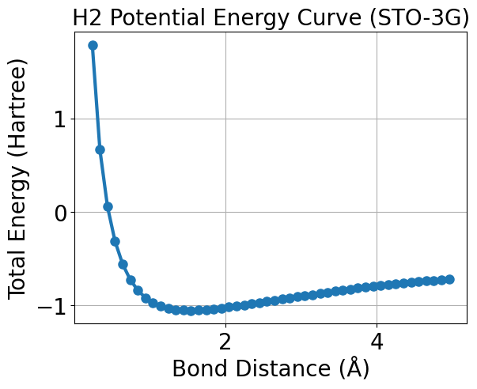

```
Minimum energy = -1.051767 Hartree at R = 1.55 Å
```

```python
# STO-3G
basis = "STO-3G"

pi = np.pi
N = 2 # Number of electrons (H2)
N_nuclei = 2
z_nuclei = 1 # Z for hydrogen
K = 2 # Number of basis functions (1 per H atom)

if basis == "STO-3G":
    alpha = np.array([0.3425250914, 0.6239137298, 0.1688554040])
    coeff = np.array([0.1543289673, 0.5353281423, 0.4446345422])
elif basis == "STO-4G":
    alpha = np.array([8.021420155, 1.467821061, 0.4077767635, 0.135337442])
    coeff = np.array([0.05675242080, 0.2601413550, 0.5328461143, 0.2916254405])
else:
    raise ValueError("Unsupported basis set")

L = len(alpha)
widths = np.zeros((L, K))
contraction_coeffs = np.zeros((L, K))
centers = np.zeros((L, K, 3))

for k in range(K):
    widths[:, k] = alpha
    contraction_coeffs[:, k] = coeff * (widths[:, k] * 2 / pi) ** (3 / 4)

bond_dist = np.arange(0.25, 5.0, 0.1)
E_total_arr = np.zeros_like(bond_dist)

for idx, R in enumerate(bond_dist):
    R_nuclei = np.zeros((N_nuclei, 3))
    R_nuclei[1, 0] = R
    for i in range(L):
        centers[i, 1, 0] = R

    S = np.zeros((K, K))
    T = np.zeros((K, K))
    U1 = np.zeros((K, K))
    U2 = np.zeros((K, K, K, K))

    for mu in range(K):
        for A in range(L):
            a = widths[A, mu]
            dA = contraction_coeffs[A, mu]
            RA = centers[A, mu]
            for nu in range(K):
                for B in range(L):
                    b = widths[B, nu]
                    dB = contraction_coeffs[B, nu]
                    RB = centers[B, nu]
                    S[mu, nu] += dA * dB * compute_overlap(a, b, RA, RB)
                    T[mu, nu] += dA * dB * compute_kinetic_energy(a, b, RA, RB)
                    for Z in range(N_nuclei):
                        U1[mu, nu] += dA * dB * z_nuclei * compute_elec_nuc_energy(a, b, RA, RB, R_nuclei[Z])
                    for lam in range(K):
                        for C in range(L):
                            g = widths[C, lam]
                            dC = contraction_coeffs[C, lam]
                            RC = centers[C, lam]
                            for sig in range(K):
                                for D in range(L):
                                    d_ = widths[D, sig]
                                    dD = contraction_coeffs[D, sig]
                                    RD = centers[D, sig]
                                    U2[mu, nu, lam, sig] += dA * dB * dC * dD * \
                                        compute_elec_elec_energy(a, b, g, d_, RA, RB, RC, RD)

    h = T + U1
    E, c = eigSinvH(S, h)
    P = np.zeros((K, K))
    n_iter = 10
    for _ in range(n_iter):
        for mu in range(K):
            for nu in range(K):
                P[mu, nu] = sum(2 * c[mu, i] * c[nu, i] for i in range(N // 2))
        F = h.copy()
        for mu in range(K):
            for nu in range(K):
                for lam in range(K):
                    for sig in range(K):
                        F[mu, nu] += P[lam, sig] * (U2[mu, nu, lam, sig] - 0.5 * U2[mu, sig, lam, nu])
        E, c = eigSinvH(S, F)

    E_elec = sum(E[:N // 2]) + 0.5 * np.trace(P @ h)
    E_nuc = z_nuclei ** 2 / np.linalg.norm(R_nuclei[0] - R_nuclei[1])
    E_total = E_elec + E_nuc
    E_total_arr[idx] = E_total

plt.plot(bond_dist, E_total_arr, marker='o')
plt.xlabel("Bond Distance (\u212B)")
plt.ylabel("Total Energy (Hartree)")
plt.title(f"H2 Potential Energy Curve ({basis})")
plt.grid(True)
plt.show()

min_idx = np.argmin(E_total_arr)
print(f"\nMinimum energy = {E_total_arr[min_idx]:.6f} Hartree at R = {bond_dist[min_idx]:.2f} \u212B")
```

```python
# STO-4G

basis = "STO-4G"

pi = np.pi
N = 2 # Number of electrons (H2)
N_nuclei = 2
z_nuclei = 1 # Z for hydrogen
K = 2 # Number of basis functions (1 per H atom)


if basis == "STO-3G":
    alpha = np.array([0.3425250914, 0.6239137298, 0.1688554040])
    coeff = np.array([0.1543289673, 0.5353281423, 0.4446345422])
elif basis == "STO-4G":
    alpha = np.array([8.021420155, 1.467821061, 0.4077767635, 0.135337442])
    coeff = np.array([0.05675242080, 0.2601413550, 0.5328461143, 0.2916254405])
else:
    raise ValueError("Unsupported basis set")

L = len(alpha)
widths = np.zeros((L, K))
contraction_coeffs = np.zeros((L, K))
centers = np.zeros((L, K, 3))

for k in range(K):
    widths[:, k] = alpha
    contraction_coeffs[:, k] = coeff * (widths[:, k] * 2 / pi) ** (3 / 4)

bond_dist = np.arange(0.25, 5.0, 0.1)
E_total_arr = np.zeros_like(bond_dist)

start_time = time.perf_counter()

for idx, R in enumerate(bond_dist):
    R_nuclei = np.zeros((N_nuclei, 3))
    R_nuclei[1, 0] = R
    for i in range(L):
        centers[i, 1, 0] = R

    S = np.zeros((K, K))
    T = np.zeros((K, K))
    U1 = np.zeros((K, K))
    U2 = np.zeros((K, K, K, K))

    for mu in range(K):
        for A in range(L):
            a = widths[A, mu]
            dA = contraction_coeffs[A, mu]
            RA = centers[A, mu]
            for nu in range(K):
                for B in range(L):
                    b = widths[B, nu]
                    dB = contraction_coeffs[B, nu]
                    RB = centers[B, nu]
                    S[mu, nu] += dA * dB * compute_overlap(a, b, RA, RB)
                    T[mu, nu] += dA * dB * compute_kinetic_energy(a, b, RA, RB)
                    for Z in range(N_nuclei):
                        U1[mu, nu] += dA * dB * z_nuclei * compute_elec_nuc_energy(a, b, RA, RB, R_nuclei[Z])
                    for lam in range(K):
                        for C in range(L):
                            g = widths[C, lam]
                            dC = contraction_coeffs[C, lam]
                            RC = centers[C, lam]
                            for sig in range(K):
                                for D in range(L):
                                    d_ = widths[D, sig]
                                    dD = contraction_coeffs[D, sig]
                                    RD = centers[D, sig]
                                    U2[mu, nu, lam, sig] += dA * dB * dC * dD * \
                                        compute_elec_elec_energy(a, b, g, d_, RA, RB, RC, RD)

    h = T + U1
    E, c = eigSinvH(S, h)
    P = np.zeros((K, K))
    n_iter = 10
    for _ in range(n_iter):
        for mu in range(K):
            for nu in range(K):
                P[mu, nu] = sum(2 * c[mu, i] * c[nu, i] for i in range(N // 2))
        F = h.copy()
        for mu in range(K):
            for nu in range(K):
                for lam in range(K):
                    for sig in range(K):
                        F[mu, nu] += P[lam, sig] * (U2[mu, nu, lam, sig] - 0.5 * U2[mu, sig, lam, nu])
        E, c = eigSinvH(S, F)

    E_elec = sum(E[:N // 2]) + 0.5 * np.trace(P @ h)
    E_nuc = z_nuclei ** 2 / np.linalg.norm(R_nuclei[0] - R_nuclei[1])
    E_total = E_elec + E_nuc
    E_total_arr[idx] = E_total

end_time = time.perf_counter()

plt.plot(bond_dist, E_total_arr, marker='o')
plt.xlabel("Bond Distance (\u212B)")
plt.ylabel("Total Energy (Hartree)")
plt.title(f"H2 Potential Energy Curve ({basis})")
plt.grid(True)
plt.show()

min_idx = np.argmin(E_total_arr)
print(f"\nMinimum energy = {E_total_arr[min_idx]:.6f} Hartree at R = {bond_dist[min_idx]:.2f} \u212B")

execution_time = end_time - start_time
print(f"\nTotal execution time: {execution_time:.4f} seconds")
```

```
Minimum energy = -1.123959 Hartree at R = 1.35 Å

Total execution time: 1.7685 seconds
```

#### 2-2 Optimize run time for HF of H2

```python
# 2-2 Optimized function definitions


from numpy import *
from numpy.linalg import *
from numpy.random import *
from matplotlib.pyplot import *
from scipy.special import binom, erf, erfc
from numba import jit


def eigSinvH(S,H):
    SinvH = inv(S) @ H
    E, U = eig(SinvH)

    order = argsort(real(E))
    c = zeros((K, K))
    for i in range(K):
        c[:, i] = real(U[:, order[i]])
        c[:, i] = c[:, i] / sqrt(c[:, i] @ S @ c[:, i])
    E = sort(real(E))
    return E, c

def compute_H_atom_energy(alpha, coeff):
    L = len(alpha)
    widths = np.zeros(L)
    contraction_coeffs = np.zeros(L)
    centers = np.zeros((L, 3))

    for i in range(L):
        widths[i] = alpha[i]
        contraction_coeffs[i] = coeff[i] * (widths[i] * 2 / np.pi) ** (3 / 4)
        centers[i] = np.zeros(3)

    S = 0.0
    T = 0.0
    U = 0.0

    for A in range(L):
        a = widths[A]
        dA = contraction_coeffs[A]
        RA = centers[A]
        for B in range(L):
            b = widths[B]
            dB = contraction_coeffs[B]
            RB = centers[B]
            S += dA * dB * compute_overlap(a, b, RA, RB)
            T += dA * dB * compute_kinetic_energy(a, b, RA, RB)
            U += dA * dB * z_nuclei * compute_elec_nuc_energy(a, b, RA, RB, np.zeros(3))  # nucleus at origin

    H_core = T + U
    E_atom = H_core / S  # Since this is a 1x1 "matrix", energy is just the scalar ratio
    return E_atom


# Function to compute the F0 integral, used in electron-nuclear and electron-electron energy calculations.
# It simplifies the evaluation of integrals involving Gaussian functions. And ensures numerical stability

def F0(x):
    if (x < 1e-8):
        return 1 - x/3
    else:
        return 0.5*sqrt(pi)*erf(sqrt(x))/sqrt(x)

@numba.jit(nopython=True)
def compute_overlap(alpha, beta, RA, RB):
    absum = alpha + beta
    abfac = alpha * beta / absum
    dRAB = RA - RB
    dRAB2 = dRAB @ dRAB
    return (pi/absum)**(3/2) * exp(-abfac * dRAB2)

@staticmethod
@numba.jit(nopython=True)
def compute_kinetic_energy(alpha, beta, RA, RB):
    absum = alpha + beta
    abfac = alpha * beta / absum
    dRAB = RA - RB
    dRAB2 = dRAB @ dRAB
    return (pi/absum)**(3/2) * exp(-abfac * dRAB2) * \
            abfac * (3 - 2*abfac * dRAB2)


def compute_elec_nuc_energy(alpha, beta, RA, RB, RC):
    absum = alpha + beta
    abfac = alpha * beta / absum
    dRAB = RA - RB
    dRAB2 = dRAB @ dRAB
    RP = (alpha*RA + beta*RB)/absum
    dRPC = RP - RC
    dRPC2 = dRPC @ dRPC
    return -(2*pi/absum)*exp(-abfac * dRAB2) * \
            F0(absum * dRPC2)


def compute_elec_elec_energy(alpha,beta,gamma,delta,RA,RB,RC,RD):
    absum = alpha + beta
    abfac = alpha * beta / absum
    dRAB = RA - RB
    dRAB2 = dRAB @ dRAB
    RP = (alpha*RA + beta*RB)/absum

    gdsum = gamma + delta
    gdfac = gamma * delta / gdsum
    dRCD = RC - RD
    dRCD2 = dRCD @ dRCD
    RQ = (gamma*RC + delta*RD) / gdsum
    dRPQ = RP - RQ
    dRPQ2 = dRPQ @ dRPQ

    abgdsum = absum + gdsum
    abgdfac = absum * gdsum / abgdsum

    return 2 * pi**(5/2) * (absum * gdsum * sqrt(abgdsum))**(-1) * \
            exp(-abfac*dRAB2 - gdfac*dRCD2) * \
            F0(abgdfac * dRPQ2) #F0 is used to compute the integral involving the distance between the electron and the nucleus.
```

```python
# STO-4G again but running after the optimized function definitions
basis = "STO-4G"

pi = np.pi
N = 2 # Number of electrons (H2)
N_nuclei = 2
z_nuclei = 1 # Z for hydrogen
K = 2 # Number of basis functions (1 per H atom)

if basis == "STO-3G":
    alpha = np.array([0.3425250914, 0.6239137298, 0.1688554040])
    coeff = np.array([0.1543289673, 0.5353281423, 0.4446345422])
elif basis == "STO-4G":
    alpha = np.array([8.021420155, 1.467821061, 0.4077767635, 0.135337442])
    coeff = np.array([0.05675242080, 0.2601413550, 0.5328461143, 0.2916254405])
else:
    raise ValueError("Unsupported basis set")

L = len(alpha)
widths = np.zeros((L, K))
contraction_coeffs = np.zeros((L, K))
centers = np.zeros((L, K, 3))

for k in range(K):
    widths[:, k] = alpha
    contraction_coeffs[:, k] = coeff * (widths[:, k] * 2 / pi) ** (3 / 4)

bond_dist = np.arange(0.25, 5.0, 0.1)
E_total_arr = np.zeros_like(bond_dist)

start_time = time.perf_counter()
for idx, R in enumerate(bond_dist):
    R_nuclei = np.zeros((N_nuclei, 3))
    R_nuclei[1, 0] = R
    for i in range(L):
        centers[i, 1, 0] = R

    S = np.zeros((K, K))
    T = np.zeros((K, K))
    U1 = np.zeros((K, K))
    U2 = np.zeros((K, K, K, K))

    for mu in range(K):
        for A in range(L):
            a = widths[A, mu]
            dA = contraction_coeffs[A, mu]
            RA = centers[A, mu]
            for nu in range(K):
                for B in range(L):
                    b = widths[B, nu]
                    dB = contraction_coeffs[B, nu]
                    RB = centers[B, nu]
                    S[mu, nu] += dA * dB * compute_overlap(a, b, RA, RB)
                    T[mu, nu] += dA * dB * compute_kinetic_energy(a, b, RA, RB)
                    for Z in range(N_nuclei):
                        U1[mu, nu] += dA * dB * z_nuclei * compute_elec_nuc_energy(a, b, RA, RB, R_nuclei[Z])
                    for lam in range(K):
                        for C in range(L):
                            g = widths[C, lam]
                            dC = contraction_coeffs[C, lam]
                            RC = centers[C, lam]
                            for sig in range(K):
                                for D in range(L):
                                    d_ = widths[D, sig]
                                    dD = contraction_coeffs[D, sig]
                                    RD = centers[D, sig]
                                    U2[mu, nu, lam, sig] += dA * dB * dC * dD * \
                                        compute_elec_elec_energy(a, b, g, d_, RA, RB, RC, RD)

    h = T + U1
    E, c = eigSinvH(S, h)
    P = np.zeros((K, K))
    n_iter = 10
    for _ in range(n_iter):
        for mu in range(K):
            for nu in range(K):
                P[mu, nu] = sum(2 * c[mu, i] * c[nu, i] for i in range(N // 2))
        F = h.copy()
        for mu in range(K):
            for nu in range(K):
                for lam in range(K):
                    for sig in range(K):
                        F[mu, nu] += P[lam, sig] * (U2[mu, nu, lam, sig] - 0.5 * U2[mu, sig, lam, nu])
        E, c = eigSinvH(S, F)

    E_elec = sum(E[:N // 2]) + 0.5 * np.trace(P @ h)
    E_nuc = z_nuclei ** 2 / np.linalg.norm(R_nuclei[0] - R_nuclei[1])
    E_total = E_elec + E_nuc
    E_total_arr[idx] = E_total

end_time = time.perf_counter()

plt.plot(bond_dist, E_total_arr, marker='o')
plt.xlabel("Bond Distance (\u212B)")
plt.ylabel("Total Energy (Hartree)")
plt.title(f"H2 Potential Energy Curve ({basis})")
plt.grid(True)
plt.show()

min_idx = np.argmin(E_total_arr)
print(f"\nMinimum energy = {E_total_arr[min_idx]:.6f} Hartree at R = {bond_dist[min_idx]:.2f} \u212B")

execution_time_improved = end_time - start_time
print(f"\nTotal execution time: {execution_time_improved:.4f} seconds")
print(f"optimized time - previous execution time: {execution_time_improved - execution_time:.4f} seconds")
```

```
Minimum energy = -1.123959 Hartree at R = 1.35 Å

Total execution time: 1.8545 seconds
optimized time - previous execution time: 0.0860 seconds
```

#### 2-3

```python
# STO-4G
basis = "STO-4G"

pi = np.pi
N = 2 # Number of electrons (H2)
N_nuclei = 2
z_nuclei = 1 # Z for hydrogen
K = 2 # Number of basis functions (1 per H atom)

if basis == "STO-3G":
    alpha = np.array([0.3425250914, 0.6239137298, 0.1688554040])
    coeff = np.array([0.1543289673, 0.5353281423, 0.4446345422])
elif basis == "STO-4G":
    alpha = np.array([8.021420155, 1.467821061, 0.4077767635, 0.135337442])
    coeff = np.array([0.05675242080, 0.2601413550, 0.5328461143, 0.2916254405])
else:
    raise ValueError("Unsupported basis set")

L = len(alpha)
widths = np.zeros((L, K))
contraction_coeffs = np.zeros((L, K))
centers = np.zeros((L, K, 3))

for k in range(K):
    widths[:, k] = alpha
    contraction_coeffs[:, k] = coeff * (widths[:, k] * 2 / pi) ** (3 / 4)

bond_dist = np.arange(0.25, 5.0, 0.1)
E_total_arr = np.zeros_like(bond_dist)

start_time = time.perf_counter()
for idx, R in enumerate(bond_dist):
    R_nuclei = np.zeros((N_nuclei, 3))
    R_nuclei[1, 0] = R
    for i in range(L):
        centers[i, 1, 0] = R

    S = np.zeros((K, K))
    T = np.zeros((K, K))
    U1 = np.zeros((K, K))
    U2 = np.zeros((K, K, K, K))

    for mu in range(K):
        for A in range(L):
            a = widths[A, mu]
            dA = contraction_coeffs[A, mu]
            RA = centers[A, mu]
            for nu in range(K):
                for B in range(L):
                    b = widths[B, nu]
                    dB = contraction_coeffs[B, nu]
                    RB = centers[B, nu]
                    S[mu, nu] += dA * dB * compute_overlap(a, b, RA, RB)
                    T[mu, nu] += dA * dB * compute_kinetic_energy(a, b, RA, RB)
                    for Z in range(N_nuclei):
                        U1[mu, nu] += dA * dB * z_nuclei * compute_elec_nuc_energy(a, b, RA, RB, R_nuclei[Z])
                    for lam in range(K):
                        for C in range(L):
                            g = widths[C, lam]
                            dC = contraction_coeffs[C, lam]
                            RC = centers[C, lam]
                            for sig in range(K):
                                for D in range(L):
                                    d_ = widths[D, sig]
                                    dD = contraction_coeffs[D, sig]
                                    RD = centers[D, sig]
                                    U2[mu, nu, lam, sig] += dA * dB * dC * dD * \
                                        compute_elec_elec_energy(a, b, g, d_, RA, RB, RC, RD)

    h = T + U1
    E, c = eigSinvH(S, h)
    P = np.zeros((K, K))
    n_iter = 10
    for _ in range(n_iter):
        for mu in range(K):
            for nu in range(K):
                P[mu, nu] = sum(2 * c[mu, i] * c[nu, i] for i in range(N // 2))
        F = h.copy()
        for mu in range(K):
            for nu in range(K):
                for lam in range(K):
                    for sig in range(K):
                        F[mu, nu] += P[lam, sig] * (U2[mu, nu, lam, sig] - 0.5 * U2[mu, sig, lam, nu])
        E, c = eigSinvH(S, F)

    E_elec = sum(E[:N // 2]) + 0.5 * np.trace(P @ h)
    E_nuc = z_nuclei ** 2 / np.linalg.norm(R_nuclei[0] - R_nuclei[1])
    E_total = E_elec + E_nuc
    E_total_arr[idx] = E_total

end_time = time.perf_counter()

plt.plot(bond_dist, E_total_arr, marker='o')
plt.xlabel("Bond Distance (\u212B)")
plt.ylabel("Total Energy (Hartree)")
plt.title(f"H2 Potential Energy Curve ({basis})")
plt.grid(True)
plt.show()

min_idx = np.argmin(E_total_arr)
print(f"\nMinimum energy = {E_total_arr[min_idx]:.6f} Hartree at R = {bond_dist[min_idx]:.2f} \u212B AKA equilibrium bond length")
E_H_atom = compute_H_atom_energy(alpha, coeff)
dissociation_energy = 2 * E_H_atom - E_total_arr[min_idx]
print(f"\nDissociation energy (D_e) = {dissociation_energy:.6f} Hartree")
```

```
Minimum energy = -1.123959 Hartree at R = 1.35 Å AKA equilibrium bond length

Dissociation energy (D_e) = 0.184347 Hartree
```

#### 2-4

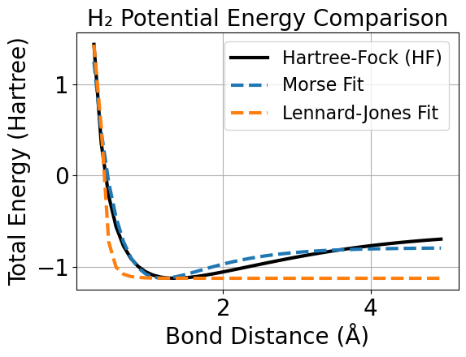

```
Morse Fit Parameters: D_e = 0.3338, a = 1.3969, r_e = 1.1798
LJ Fit Parameters: ε = -4.2495, σ = 0.2417
```

```python
from scipy.optimize import curve_fit

def morse_potential(r, D_e, a, r_e):
    return D_e * (1 - np.exp(-a * (r - r_e)))**2

r_vals = bond_dist
hf_vals = E_total_arr
E_min = np.min(hf_vals)
D_e_init = hf_vals[-1] - E_min
r_e_init = bond_dist[np.argmin(hf_vals)]

popt_morse, _ = curve_fit(morse_potential, r_vals, hf_vals - E_min, p0=[D_e_init, 1.0, r_e_init])
morse_fit = morse_potential(r_vals, *popt_morse) + E_min

def lj_potential(r, epsilon, sigma):
    return 4 * epsilon * ((sigma / r)**12 - (sigma / r)**6)

popt_lj, _ = curve_fit(lj_potential, r_vals, hf_vals - E_min, p0=[0.1, 2.0], maxfev=100000)
lj_fit = lj_potential(r_vals, *popt_lj) + E_min

plt.plot(r_vals, hf_vals, 'k-', label='Hartree-Fock (HF)')
plt.plot(r_vals, morse_fit, '--', label='Morse Fit')
plt.plot(r_vals, lj_fit, '--', label='Lennard-Jones Fit')
plt.xlabel("Bond Distance (Å)")
plt.ylabel("Total Energy (Hartree)")
plt.title("H₂ Potential Energy Comparison")
plt.legend()
plt.grid(True)
plt.tight_layout()
plt.show()

print(f"\nMorse Fit Parameters: D_e = {popt_morse[0]:.4f}, a = {popt_morse[1]:.4f}, r_e = {popt_morse[2]:.4f}")
print(f"LJ Fit Parameters: ε = {popt_lj[0]:.4f}, σ = {popt_lj[1]:.4f}")
```

Fit analysis:

- Morse provides is a decent fit with a accurate minimim and some agreement at large bond distances.
- LJ diverges from the others at short bond distances and flattens too early. This makes sense because LJ is not a good model for covalent bonding like in H2.

To minimize disparities between the potential energy surface calculated and actual electronic structure, we could choose a basis set that contains more functions and include electron correlation methods like MP2 or CCSD.

## Project 3: Path-integral MC for the hydrogen molecule

Morse potential: $$ V(r) = D_e \left( 1 - e^{-a(r - r_{\text{eq}})} \right)^2 - D_e $$

Virial theorem relates average KE to average PE by:
$$ \langle T \rangle = \frac{1}{2} \left\langle r \cdot \frac{dV(r)}{dr} \right\rangle $$

So the total energy is:

$$ E = \langle T \rangle + \langle V \rangle = \frac{1}{2} \left\langle r \cdot \frac{dV(r)}{dr} \right\rangle + \left\langle V(r) \right\rangle $$

Calculating the gradient of V wrt r gives: $$ \frac{dV(r)}{dr} = 2aD_e \left( 1 - e^{-a(r - r_{\text{eq}})} \right) e^{-a(r - r_{\text{eq}})} $$

Thus, the total energy is: $$ E = \left\langle D_e \left( 1 - e^{-a(r - r_{\text{eq}})} \right)^2 - D_e \right\rangle + \left\langle \frac{1}{2} r \cdot 2aD_e \left( 1 - e^{-a(r - r_{\text{eq}})} \right) e^{-a(r - r_{\text{eq}})} \right\rangle $$

```python
# 3-1 Virial theorem for total energy

import numpy as np
import matplotlib.pyplot as plt
import numba

@numba.jit(nopython=True)
def morse_potential(r):
    D_e = 4.7446 # eV
    a = 1.44 # Angstrom^-1
    r_e = 0.74 # Angstrom
    return D_e * (1 - np.exp(-a * (r - r_e)))**2 - D_e

@numba.jit(nopython=True)
def gradient(r):
    D_e = 4.7446 # eV
    a = 1.44 # Angstrom^-1
    r_e = 0.74 # Angstrom
    return 2 * D_e * a * np.exp(-a * (r - r_e)) * (1 - np.exp(-a * (r - r_e)))

@numba.jit(nopython=True)
def virial_energy(r_vals):
    V_vals = morse_potential(r_vals)
    F_vals = gradient(r_vals)
    return np.mean(V_vals + 0.5 * r_vals * F_vals)
```

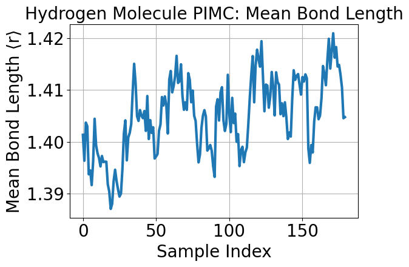

```python
# 3-2 PIMC for H2 using the Morse potential and ring polymer

import numpy as np
import matplotlib.pyplot as plt
import numba

# Parameters
k = 15                      # Number of beads per particle
L = 10.0                     # Box size
steps = 100000               # Total number of Monte Carlo steps
delta = 0.82                 # Max displacement
kBT = 3.167e-6 * 1000       # Temperature in atomic units
beta = 1 / kBT
mass = 1836.0
tau = beta / k

# Morse potential parameters
De = 4.7446/27.211
a = 1.440558/1.89
req = 0.7416*1.89

# Initialize bead positions randomly in box
@numba.jit(nopython=True)
def initialize_beads(k, L):
    return np.random.uniform(0, L/k, size=k)


# Periodic distance (minimum image)
@numba.jit(nopython=True)
def dist(x1, x2):
    dx = x1 - x2
    dx -= L * np.round(dx / L)
    return dx

# Morse potential
@numba.jit(nopython=True)
def morse(r):
    return De * (1 - np.exp(-a * (r - req)))**2 - De

# Action change for trial move
@numba.jit(nopython=True)
def delta_action(e, h, particle, bead, trial_pos, k):
    # Original positions
    if particle == 0:
        old = e[bead]
    else:
        old = h[bead]

    # Indices for neighboring beads
    prev = (bead - 1) % k
    next = (bead + 1) % k

    # Compute old kinetic energy
    if particle == 0:
        ke_old = (dist(e[next], old)**2 + dist(e[prev], old)**2) * (mass / (2 * tau**2))
        pe_old = morse(np.abs(dist(old, h[bead])))
    else:
        ke_old = (dist(h[next], old)**2 + dist(h[prev], old)**2) * (mass / (2 * tau**2))
        pe_old = morse(np.abs(dist(e[bead], old)))

    # Compute new kinetic energy
    if particle == 0:
        ke_new = (dist(e[next], trial_pos)**2 + dist(e[prev], trial_pos)**2) * (mass / (2 * tau**2))
        pe_new = morse(np.abs(dist(trial_pos, h[bead])))
    else:
        ke_new = (dist(h[next], trial_pos)**2 + dist(h[prev], trial_pos)**2) * (mass / (2 * tau**2))
        pe_new = morse(np.abs(dist(e[bead], trial_pos)))

    return tau * (ke_new + pe_new - ke_old - pe_old)

# Monte Carlo sweep
@numba.jit(nopython=True)
def mc_sweep(e, h, k, count):
    for _ in range(2 * k):
        idx = np.random.randint(0, 2 * k)
        if idx < k:
            particle = 0
            bead = idx
        else:
            particle = 1
            bead = idx % k

        trial_pos = (e[bead] if particle == 0 else h[bead]) + 2 * delta * (np.random.rand() - 0.5)
        #trial_pos %= L  # Periodic boundary

        dS = delta_action(e, h, particle, bead, trial_pos, k)

        if np.random.rand() < np.exp(-dS / kBT):
            if particle == 0:
                e[bead] = trial_pos%L
            else:
                h[bead] = trial_pos%L
            count += 1
    return e, h, count

# Initialize system
e = initialize_beads(k, L)
h = initialize_beads(k, L)

count = 0
samples = []

# Run simulation
burn_in = 10000  # number of MC steps to discard
for step in range(steps):
    e, h, count = mc_sweep(e, h, k, count)
    if step >= burn_in and step % 500 == 0:
        r = np.array([np.abs(dist(e[i], h[i])) for i in range(k)])
        samples.append(np.mean(r))
#         for i in range(k):
#             r = np.abs(dist(e[i], h[i]))
#             samples.append(r)

# Plot mean bond length
plt.plot(samples)
plt.xlabel('Sample Index')
plt.ylabel('Mean Bond Length ⟨r⟩')
plt.title('Hydrogen Molecule PIMC: Mean Bond Length')
plt.grid(True)
plt.tight_layout()
plt.show()
```

```python
# 3-3 Accelerate MC convergence by adding moves that translate the entire ring polymer
import numpy as np
import numba

# Parameters (same as before)
k = 10
L = 10.0
delta = 0.82
kBT = 3.167e-6 * 2000
beta = 1 / kBT
mass = 1836.153
tau = beta / k
De = 4.7446/27.211
a = 1.440558/1.89
req = 0.7416*1.89

# Periodic distance function
@numba.jit(nopython=True)
def dist(x1, x2):
    dx = x1 - x2
    dx -= L * np.round(dx / L)
    return dx

# Morse potential
@numba.jit(nopython=True)
def morse(r):
    return De * (1 - np.exp(-a * (r - req)))**2 - De

# Total interaction energy between beads of e and h
@numba.jit(nopython=True)
def total_potential(e, h, k):
    V = 0.0
    for i in range(k):
        V += morse(np.abs(dist(e[i], h[i])))
    return V

# Delta action for local bead move
@numba.jit(nopython=True)
def delta_action(e, h, particle, bead, trial_pos, k):
    if particle == 0:
        old = e[bead]
        prev, next1 = (bead - 1) % k, (bead + 1) % k
        ke_old = (dist(e[next1], old)**2 + dist(e[prev], old)**2) * (mass / (2 * tau**2))
        ke_new = (dist(e[next1], trial_pos)**2 + dist(e[prev], trial_pos)**2) * (mass / (2 * tau**2))
        pe_old = morse(np.abs(dist(old, h[bead])))
        pe_new = morse(np.abs(dist(trial_pos, h[bead])))
    else:
        old = h[bead]
        prev, next1 = (bead - 1) % k, (bead + 1) % k
        ke_old = (dist(h[next1], old)**2 + dist(h[prev], old)**2) * (mass / (2 * tau**2))
        ke_new = (dist(h[next1], trial_pos)**2 + dist(h[prev], trial_pos)**2) * (mass / (2 * tau**2))
        pe_old = morse(np.abs(dist(e[bead], old)))
        pe_new = morse(np.abs(dist(e[bead], trial_pos)))

    return tau * (ke_new + pe_new - ke_old - pe_old)

# Monte Carlo sweep with whole-polymer moves
@numba.jit(nopython=True)
def mc_sweep_with_polymer_moves(e, h, k, count):
    for _ in range(2 * k + 2):
        idx = np.random.randint(0, 2 * k + 2)

        if idx < k:
            # bead move in e
            bead = idx
            trial = (e[bead] + 2 * delta * (np.random.rand() - 0.5))
            dS = delta_action(e, h, 0, bead, trial, k)
            if np.random.rand() < np.exp(-dS / kBT):
                e[bead] = trial%L
                count += 1
#Have to be careful with this index
#        elif idx < 2 * k:
        elif idx < 2 * k and idx >= k:
            # bead move in h
            bead = idx%k
            trial = (h[bead] + 2 * delta * (np.random.rand() - 0.5))
            dS = delta_action(e, h, 1, bead, trial, k)
            if np.random.rand() < np.exp(-dS / kBT):
                h[bead] = trial%L
                count += 1

        elif idx == 2 * k:
            # whole-polymer move for e
            shift = 2 * delta * (np.random.rand() - 0.5)
            e_trial = (e + shift)
            V_old = total_potential(e, h, k)
            V_new = total_potential(e_trial, h, k)
            dS = tau * (V_new - V_old)
            if np.random.rand() < np.exp(-dS / kBT):
                e = e_trial%L
                count += 1

        else:
            # whole-polymer move for h
            shift = 2 * delta * (np.random.rand() - 0.5)
            h_trial = (h + shift)
            V_old = total_potential(e, h, k)
            V_new = total_potential(e, h_trial, k)
            dS = tau * (V_new - V_old)
            if np.random.rand() < np.exp(-dS / kBT):
                h = h_trial%L
                count += 1

    return e, h, count
```

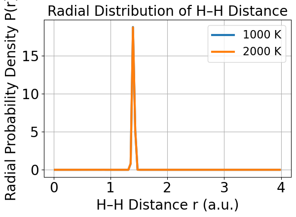

```
Average total energy at 1000 K: -0.17430 ± 0.00005
Average total energy at 2000 K: -0.17429 ± 0.00005
```

```python
# 3-4 PIMC for H2 at different temperatures, compute average total energy

import matplotlib.pyplot as plt

@numba.jit(nopython=True)
def total_energ(e, h, k):
    V = 0.0
    for i in range(k):
        r = np.abs(dist(e[i], h[i]))
        V +=  De*(1-np.exp(-a*(r-req)))**2 - De +0.5*2*r*De*a*(1-np.exp(-a*(r-req)))*np.exp(-a*(r-req))
    return V/k

@numba.jit(nopython=True)
# Reuse existing functions, but modify for temperature sweep
def run_pimc_temperature(k, T, steps=500000, delta=0.82, L=10.0, Nsamp=500):
    kBT = 3.167e-6 * T
    beta = 1 / kBT
    tau = beta / k
    e = np.random.uniform(0, L/k, size=k)
    h = np.random.uniform(0, L/k, size=k)
    count = 0
    energy_samples = []
    r_samples = []

    for step in range(steps):
        e, h, count = mc_sweep_with_polymer_moves(e, h, k, count)
        if step % Nsamp == 0:
            # Sample potential energy
            #V = total_potential(e, h, k)
            # Estimate KE from bead curvature (primitive estimator)
            #T_e = sum((dist(e[(i+1)%k], e[i])**2 for i in range(k))) * (mass / (2 * tau**2))
            #T_h = sum((dist(h[(i+1)%k], h[i])**2 for i in range(k))) * (mass / (2 * tau**2))
            #KE = tau * (T_e + T_h)
            energy_samples.append(total_energ(e, h, k))

            for i in range(k):
                r_samples.append(np.abs(dist(e[i], h[i])))

    return np.array(energy_samples[200:]), np.array(r_samples)

E_1000K, R_1000K = run_pimc_temperature(k=40, T=1000)
E_2000K, R_2000K = run_pimc_temperature(k=40, T=2000)

fig, ax = plt.subplots()
bins = np.linspace(0, 4, 100)

P_1000K, bin_edges = np.histogram(R_1000K, bins=bins, density=True)
P_2000K, _ = np.histogram(R_2000K, bins=bins, density=True)

bin_centers = 0.5 * (bin_edges[:-1] + bin_edges[1:])

ax.plot(bin_centers, P_1000K, label='1000 K')
ax.plot(bin_centers, P_2000K, label='2000 K')
ax.set_xlabel('H–H Distance r (a.u.)')
ax.set_ylabel('Radial Probability Density P(r)')
ax.set_title('Radial Distribution of H–H Distance')
ax.legend()
ax.grid(True)
plt.tight_layout()
plt.show()

mean_E_1000K = np.mean(E_1000K)
acf_1000K = compute_normalized_acf(E_1000K)
tau_int_1000K = estimate_correlation_lag(acf_1000K)
N_eff_1000K = len(E_1000K) / (2 * tau_int_1000K)
err_E_1000K = np.std(E_1000K) / np.sqrt(N_eff_1000K)


mean_E_2000K = np.mean(E_2000K)
acf_2000K = compute_normalized_acf(E_2000K)
tau_int_2000K = estimate_correlation_lag(acf_2000K)
N_eff_2000K = len(E_2000K) / (2 * tau_int_2000K)
err_E_2000K = np.std(E_2000K) / np.sqrt(N_eff_2000K)

print(f"Average total energy at 1000 K: {mean_E_1000K:.5f} ± {err_E_1000K:.5f}")
print(f"Average total energy at 2000 K: {mean_E_2000K:.5f} ± {err_E_2000K:.5f}")
```

## Project 4: Phase diagram of Lennard-Jones particles

#### # 4-1 through 4-3

```python
# 4-1 through 4-3
import numba
import numpy as np
import matplotlib.pyplot as plt
import matplotlib as mpl
mpl.rcParams['lines.linewidth'] = 3
mpl.rcParams['lines.markersize'] = 8
mpl.rcParams['font.size'] = 20
mpl.rcParams['axes.labelsize'] = 20
mpl.rcParams['axes.titlesize'] = 20
mpl.rcParams['xtick.labelsize'] = 20
mpl.rcParams['ytick.labelsize'] = 20
mpl.rcParams['legend.fontsize'] = 16
mpl.rcParams['figure.titlesize'] = 20

class SoftSphereSystem:
    def __init__(self, NX, RHO, T, dt, Nsamp, M, include_rescale=True):
        self.NX = NX
        self.N = NX ** 3
        self.RHO = RHO
        self.T = T
        self.dt = dt
        self.Nsamp = Nsamp
        self.M = M
        self.include_rescale = include_rescale

        self.time = 0.0

        self.x = np.zeros([self.N, 3])
        self.v = np.zeros([self.N, 3])
        self.f = np.zeros([self.N, 3]) # forces at the current time step
        self.f1 = np.zeros([self.N, 3]) # forces at the next time step

        self.LX = (self.N / self.RHO) ** (1. / 3.)
        self.x, self.v = self.initialize(self.x, self.v, self.LX, self.NX, self.T)

    @staticmethod
    @numba.jit(nopython=True)
    def initialize(x, v, L, Nx, T):
        dx = L / Nx
        sigma = T ** 0.5
        n = 0
        for i in range(Nx):
            for j in range(Nx):
                for k in range(Nx):
                    x[n, 0] = i * dx
                    x[n, 1] = j * dx
                    x[n, 2] = k * dx
                    v[n, 0] = np.random.normal(0, sigma)
                    v[n, 1] = np.random.normal(0, sigma)
                    v[n, 2] = np.random.normal(0, sigma)
                    n = n + 1

        v[:, 0] = v[:, 0] - sum(v[:, 0]) / (n - 1)
        v[:, 1] = v[:, 1] - sum(v[:, 1]) / (n - 1)
        v[:, 2] = v[:, 2] - sum(v[:, 2]) / (n - 1)

        return x, v

    @staticmethod
    @numba.jit(nopython=True)
    def rescale_velocities(v, T_desired, N):
        current_temp = np.sum(v ** 2) / (3 * N)
        scaling_factor = np.sqrt(T_desired / current_temp)
        v *= scaling_factor
        return v

    @staticmethod
    @numba.jit(nopython=True)
    def force(x, f, Lx, N):
        f = np.zeros((N, 3))
        for i in range(N):
            for j in range(i + 1, N):
                dx = x[i, 0] - x[j, 0]
                dx = dx - Lx * np.round(dx / Lx)
                dy = x[i, 1] - x[j, 1]
                dy = dy - Lx * np.round(dy / Lx)
                dz = x[i, 2] - x[j, 2]
                dz = dz - Lx * np.round(dz / Lx)

                r = np.sqrt(dx * dx + dy * dy + dz * dz)
                if r < 1.112:
                    fac = 4 * (12. / r ** 14. - 6. / r ** 8.)
                    f[i, 0] = f[i, 0] + fac * dx
                    f[j, 0] = f[j, 0] - fac * dx
                    f[i, 1] = f[i, 1] + fac * dy
                    f[j, 1] = f[j, 1] - fac * dy
                    f[i, 2] = f[i, 2] + fac * dz
                    f[j, 2] = f[j, 2] - fac * dz

        return f

    @staticmethod
    @numba.jit(nopython=True)
    def potential(x, Lx, N):
        pe = 0.
        for i in range(N):
            for j in range(N):
                if i == j: continue
                dx = x[i, 0] - x[j, 0]
                dx = dx - Lx * np.round(dx / Lx)
                dy = x[i, 1] - x[j, 1]
                dy = dy - Lx * np.round(dy / Lx)
                dz = x[i, 2] - x[j, 2]
                dz = dz - Lx * np.round(dz / Lx)
                r = np.sqrt(dx * dx + dy * dy + dz * dz)
                if r < 1.112:
                    pe = pe + 4. * (1. / r ** 12. - 1. / r ** 6.) + 1.
        return pe / 2.

    @staticmethod
    @numba.jit(nopython=True)
    def verlet_step(x, v, f, f1, Lx, dt, N, force_func):
        f = force_func(x, f, Lx, N)
        x += v * dt + f * dt ** 2. / 2.
        f1 = force_func(x, f1, Lx, N)
        v += (f + f1) * dt / 2.
        #x = x % Lx
        return x, v

    def run_simulation(self, rescale_time, run_time, output_file):
        rescale_steps = int(rescale_time / self.dt  + 0.5) # Number of steps to rescale velocities
        run_steps = int(run_time / self.dt + 0.5) # Number of steps to run without rescaling
        record_steps =  (rescale_steps * self.include_rescale + run_steps) // self.Nsamp + 1 # Total number of steps to record

        positions_list = np.zeros((record_steps, self.N, 3))
        velocities_list = np.zeros((record_steps, self.N, 3))
        time_list = np.zeros(record_steps)
        count_steps = 0

        # Perform steps integrations with rescaling
        for i in range(rescale_steps):
            self.x, self.v = self.verlet_step(self.x, self.v, self.f, self.f1, self.LX, self.dt, self.N, self.force)
            self.time += self.dt

            # Rescale velocities every M steps
            if i % self.M == 0:
                self.v = self.rescale_velocities(self.v, self.T, self.N)

            if self.include_rescale and i % self.Nsamp == 0:
                positions_list[count_steps] = self.x.copy()
                velocities_list[count_steps] = self.v.copy()
                time_list[count_steps] = self.time
                count_steps += 1
                #print(f"Time: {self.time:.3f}")
        if not self.include_rescale:
            self.time = 0.0
        for i in range(run_steps):
            self.x, self.v = self.verlet_step(self.x, self.v, self.f, self.f1, self.LX, self.dt, self.N, self.force)
            self.time += self.dt

            if i % self.Nsamp == 0:
                positions_list[count_steps] = self.x.copy()
                velocities_list[count_steps] = self.v.copy()
                time_list[count_steps] = self.time
                count_steps += 1
                #print(f"Time: {self.time:.3f}")

        # Save all positions and velocities to a single file
        # If you were to run a long simulation you would want to do this several times during the simulation as checkpoints
        np.savez(output_file, times=np.array(time_list[:count_steps]), positions=np.array(positions_list[:count_steps]), velocities=np.array(velocities_list[:count_steps]))

    @staticmethod
    def load_simulation_data(file):
        data = np.load(file)
        times = data['times']
        positions = data['positions']
        velocities = data['velocities']
        return times, positions, velocities

    @staticmethod
    def compute_energies(positions, velocities, Lx, N):
        kinetic_energies = []
        potential_energies = []
        total_energies = []

        for i in range(len(positions)):
            ke = 0.5 * np.sum(velocities[i] ** 2)
            pe = SoftSphereSystem.potential(positions[i], Lx, N)
            kinetic_energies.append(ke)
            potential_energies.append(pe)
            total_energies.append(ke + pe)

        return np.array(kinetic_energies), np.array(potential_energies), np.array(total_energies)

    @staticmethod
    def compute_mean_square_displacement(tf, positions, dt, shift_t):
        n = int(tf // dt) # How far out to compute the correlation function
        q = int(shift_t // dt) # How far to shift the time series
        M = len(velocities)
        N = len(velocities[0])
        shifts =len(range(0, M - n, q))
        return np.array([
                (1. / N) * np.sum(
                    np.array([
                        (1 / shifts ) * np.sum(
                            np.array([
                                np.sum( (positions[i + j][l] - positions[i][l]) ** 2) for i in range(0, M - n, q)
                            ])
                        ) for l in range(N)
                    ])
                ) for j in range(n)
            ])

    @staticmethod
    def compute_velocity_autocorrelation(tf, velocities, dt, shift_t):
        n = int(tf // dt) # How far out to compute the correlation function
        q = int(shift_t // dt) # How far to shift the time series
        M = len(velocities)
        N = len(velocities[0])
        shifts =len(range(0, M - n, q))
        return np.array([
                (1. / (3. * N ) ) * np.sum(
                    np.array([
                        (1 / shifts ) * np.sum(
                            np.array([
                                np.dot (velocities[i + j][l], velocities[i][l] ) for i in range(0, M - n, q)
                            ])
                        ) for l in range(N)
                    ])
                ) for j in range(n)
            ])
```

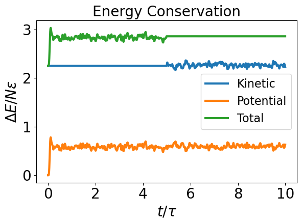

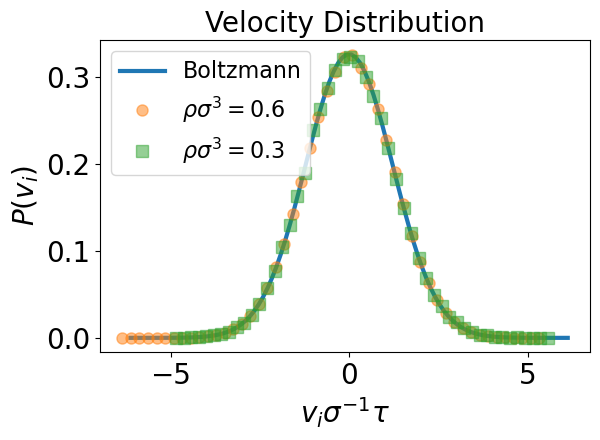

```python
if __name__ == "__main__":

    # Parameters
    nx = 8 # Number of particles in each direction
    rho = 0.6 # Density in units of sigma^{-3}
    temperature = 1.5 # Temperature in units of epsilon/k_B
    dt = 0.001 # Time step in LJ time units
    Nsamp = 10 # Save positions and velocities every Nsamp steps
    M = 5  # Rescale velocities every M steps

    ############################################################
    # Checking energy conservation and rescaling velocities

    # Simulation periods in LJ time units
    rescale_time = 5.0  # Time with rescaling
    run_time = 5.0  # Time without rescaling

    output_file = "./output_file.npz"
    system = SoftSphereSystem(nx, rho, temperature, dt, Nsamp, M, include_rescale=True)
    system.run_simulation(rescale_time, run_time, output_file)

    # Load simulation data
    times, positions, velocities = SoftSphereSystem.load_simulation_data(output_file)

    # Plot energies
    kinetic_energies, potential_energies, total_energies = SoftSphereSystem.compute_energies(positions, velocities, system.LX, system.N)
    plt.plot(times, kinetic_energies / system.N, label='Kinetic')
    plt.plot(times, potential_energies / system.N, label='Potential')
    plt.plot(times, total_energies / system.N, label='Total')
    plt.xlabel(r'$t/\tau$')
    plt.ylabel(r'$\Delta E/N\epsilon$')
    plt.title(r"Energy Conservation")
    plt.legend()
    plt.tight_layout()
    plt.show()

    ############################################################
    # Checking Enemble Equivalence

    # Calculate canonical distribution out to 5 sigma
    v_range = np.linspace(-5 * np.sqrt(system.T), 5 * np.sqrt(system.T), 100)
    boltzmann_distribution = np.array( [ np.exp(-(v ** 2) / (2 * system.T)) for v in v_range ] )
    boltzmann_distribution /= np.sum(boltzmann_distribution * (v_range[1] - v_range[0]))
    plt.plot(v_range, boltzmann_distribution, label='Boltzmann')

    run_time = 15.0
    system = SoftSphereSystem(nx, rho, temperature, dt, Nsamp, M, include_rescale=False)
    system.run_simulation(rescale_time, run_time, "high_density.npz")
    times, positions, velocities = SoftSphereSystem.load_simulation_data("high_density.npz")
    hist, bins = np.histogram(velocities.flatten(), bins=50, density=True)
    bin_centers = (bins[1:] + bins[:-1]) / 2
    plt.plot(bin_centers, hist, label=r"$\rho\sigma^{3}= %.1f$" % system.RHO, alpha=0.5, linestyle='None', marker='o')

    # Repeat at a lower density
    rho = 0.3
    system = SoftSphereSystem(nx, rho, temperature, dt, Nsamp, M, include_rescale=False)
    system.run_simulation(rescale_time, run_time, "low_density.npz")
    times, positions, velocities = SoftSphereSystem.load_simulation_data("low_density.npz")
    hist, bins = np.histogram(velocities.flatten(), bins=50, density=True)
    bin_centers = (bins[1:] + bins[:-1]) / 2
    plt.plot(bin_centers, hist, label=r"$\rho\sigma^{3}= %.1f$" % system.RHO, alpha=0.5, linestyle='None', marker='s')
    plt.xlabel(r"$v_i \sigma^{-1}\tau$")
    plt.ylabel(r"$P(v_i)$")
    plt.title(r"Velocity Distribution")
    plt.legend()
    plt.tight_layout()
    plt.show()
```

```python
# 4-4 Initilize FCC lattice instead of simple cubic
import numba
import numpy as np
import matplotlib.pyplot as plt
import matplotlib as mpl
mpl.rcParams['lines.linewidth'] = 3
mpl.rcParams['lines.markersize'] = 8
mpl.rcParams['font.size'] = 20
mpl.rcParams['axes.labelsize'] = 20
mpl.rcParams['axes.titlesize'] = 20
mpl.rcParams['xtick.labelsize'] = 20
mpl.rcParams['ytick.labelsize'] = 20
mpl.rcParams['legend.fontsize'] = 16
mpl.rcParams['figure.titlesize'] = 20

class SoftSphereSystem:
    def __init__(self, NX, RHO, T, dt, Nsamp, M, include_rescale=True):
        self.NX = NX
        self.N = 4 * NX ** 3 # FCC lattice has 4 atoms per unit cell
        self.RHO = RHO
        self.T = T
        self.dt = dt
        self.Nsamp = Nsamp
        self.M = M
        self.include_rescale = include_rescale

        self.time = 0.0

        self.x = np.zeros([self.N, 3])
        self.v = np.zeros([self.N, 3])
        self.f = np.zeros([self.N, 3]) # forces at the current time step
        self.f1 = np.zeros([self.N, 3]) # forces at the next time step

        self.LX = (self.N / self.RHO) ** (1. / 3.)
        self.x, self.v = self.initialize_fcc(self.x, self.v, self.LX, self.NX, self.T) # Initialize FCC lattice instead of simple cubic

    @staticmethod
    @numba.jit(nopython=True)
    def initialize(x, v, L, Nx, T):
        dx = L / Nx
        sigma = T ** 0.5
        n = 0
        for i in range(Nx):
            for j in range(Nx):
                for k in range(Nx):
                    x[n, 0] = i * dx
                    x[n, 1] = j * dx
                    x[n, 2] = k * dx
                    v[n, 0] = np.random.normal(0, sigma)
                    v[n, 1] = np.random.normal(0, sigma)
                    v[n, 2] = np.random.normal(0, sigma)
                    n = n + 1

        v[:, 0] = v[:, 0] - sum(v[:, 0]) / (n - 1)
        v[:, 1] = v[:, 1] - sum(v[:, 1]) / (n - 1)
        v[:, 2] = v[:, 2] - sum(v[:, 2]) / (n - 1)

        return x, v

    @staticmethod
    @numba.jit(nopython=True)
    def rescale_velocities(v, T_desired, N):
        current_temp = np.sum(v ** 2) / (3 * N)
        scaling_factor = np.sqrt(T_desired / current_temp)
        v *= scaling_factor
        return v

    @staticmethod
    @numba.jit(nopython=True)
    def force(x, f, Lx, N):
        f = np.zeros((N, 3))
        for i in range(N):
            for j in range(i + 1, N):
                dx = x[i, 0] - x[j, 0]
                dx = dx - Lx * np.round(dx / Lx)
                dy = x[i, 1] - x[j, 1]
                dy = dy - Lx * np.round(dy / Lx)
                dz = x[i, 2] - x[j, 2]
                dz = dz - Lx * np.round(dz / Lx)

                r = np.sqrt(dx * dx + dy * dy + dz * dz)
                if r < 1.112:
                    fac = 4 * (12. / r ** 14. - 6. / r ** 8.)
                    f[i, 0] = f[i, 0] + fac * dx
                    f[j, 0] = f[j, 0] - fac * dx
                    f[i, 1] = f[i, 1] + fac * dy
                    f[j, 1] = f[j, 1] - fac * dy
                    f[i, 2] = f[i, 2] + fac * dz
                    f[j, 2] = f[j, 2] - fac * dz

        return f

    @staticmethod
    @numba.jit(nopython=True)
    def potential(x, Lx, N):
        pe = 0.
        for i in range(N):
            for j in range(N):
                if i == j: continue
                dx = x[i, 0] - x[j, 0]
                dx = dx - Lx * np.round(dx / Lx)
                dy = x[i, 1] - x[j, 1]
                dy = dy - Lx * np.round(dy / Lx)
                dz = x[i, 2] - x[j, 2]
                dz = dz - Lx * np.round(dz / Lx)
                r = np.sqrt(dx * dx + dy * dy + dz * dz)
                if r < 1.112:
                    pe = pe + 4. * (1. / r ** 12. - 1. / r ** 6.) + 1.
        return pe / 2.

    @staticmethod
    @numba.jit(nopython=True)
    def verlet_step(x, v, f, f1, Lx, dt, N, force_func):
        f = force_func(x, f, Lx, N)
        x += v * dt + f * dt ** 2. / 2.
        f1 = force_func(x, f1, Lx, N)
        v += (f + f1) * dt / 2.
        #x = x % Lx
        return x, v

    def run_simulation(self, rescale_time, run_time, output_file):
        rescale_steps = int(rescale_time / self.dt  + 0.5) # Number of steps to rescale velocities
        run_steps = int(run_time / self.dt + 0.5) # Number of steps to run without rescaling
        record_steps =  (rescale_steps * self.include_rescale + run_steps) // self.Nsamp + 1 # Total number of steps to record

        positions_list = np.zeros((record_steps, self.N, 3))
        velocities_list = np.zeros((record_steps, self.N, 3))
        time_list = np.zeros(record_steps)
        count_steps = 0

        # Perform steps integrations with rescaling
        for i in range(rescale_steps):
            self.x, self.v = self.verlet_step(self.x, self.v, self.f, self.f1, self.LX, self.dt, self.N, self.force)
            self.time += self.dt

            # Rescale velocities every M steps
            if i % self.M == 0:
                self.v = self.rescale_velocities(self.v, self.T, self.N)

            if self.include_rescale and i % self.Nsamp == 0:
                positions_list[count_steps] = self.x.copy()
                velocities_list[count_steps] = self.v.copy()
                time_list[count_steps] = self.time
                count_steps += 1
                #print(f"Time: {self.time:.3f}")
        if not self.include_rescale:
            self.time = 0.0
        for i in range(run_steps):
            self.x, self.v = self.verlet_step(self.x, self.v, self.f, self.f1, self.LX, self.dt, self.N, self.force)
            self.time += self.dt

            if i % self.Nsamp == 0:
                positions_list[count_steps] = self.x.copy()
                velocities_list[count_steps] = self.v.copy()
                time_list[count_steps] = self.time
                count_steps += 1
                #print(f"Time: {self.time:.3f}")

        # Save all positions and velocities to a single file
        # If you were to run a long simulation you would want to do this several times during the simulation as checkpoints
        np.savez(output_file, times=np.array(time_list[:count_steps]), positions=np.array(positions_list[:count_steps]), velocities=np.array(velocities_list[:count_steps]))

    @staticmethod
    def load_simulation_data(file):
        data = np.load(file)
        times = data['times']
        positions = data['positions']
        velocities = data['velocities']
        return times, positions, velocities

    @staticmethod
    def compute_energies(positions, velocities, Lx, N):
        kinetic_energies = []
        potential_energies = []
        total_energies = []

        for i in range(len(positions)):
            ke = 0.5 * np.sum(velocities[i] ** 2)
            pe = SoftSphereSystem.potential(positions[i], Lx, N)
            kinetic_energies.append(ke)
            potential_energies.append(pe)
            total_energies.append(ke + pe)

        return np.array(kinetic_energies), np.array(potential_energies), np.array(total_energies)

    @staticmethod
    def compute_mean_square_displacement(tf, positions, dt, shift_t):
        n = int(tf // dt) # How far out to compute the correlation function
        q = int(shift_t // dt) # How far to shift the time series
        M = len(velocities)
        N = len(velocities[0])
        shifts =len(range(0, M - n, q))
        return np.array([
                (1. / N) * np.sum(
                    np.array([
                        (1 / shifts ) * np.sum(
                            np.array([
                                np.sum( (positions[i + j][l] - positions[i][l]) ** 2) for i in range(0, M - n, q)
                            ])
                        ) for l in range(N)
                    ])
                ) for j in range(n)
            ])

    @staticmethod
    def compute_velocity_autocorrelation(tf, velocities, dt, shift_t):
        n = int(tf // dt) # How far out to compute the correlation function
        q = int(shift_t // dt) # How far to shift the time series
        M = len(velocities)
        N = len(velocities[0])
        shifts =len(range(0, M - n, q))
        return np.array([
                (1. / (3. * N ) ) * np.sum(
                    np.array([
                        (1 / shifts ) * np.sum(
                            np.array([
                                np.dot (velocities[i + j][l], velocities[i][l] ) for i in range(0, M - n, q)
                            ])
                        ) for l in range(N)
                    ])
                ) for j in range(n)
            ])

    @staticmethod
    @numba.jit(nopython=True)
    def initialize_fcc(x, v, L, n_cells, T):
        # FCC has 4 atoms per unit cell at:
        # (0, 0, 0), (0.5, 0.5, 0), (0.5, 0, 0.5), (0, 0.5, 0.5)
        a = L / n_cells  # FCC unit cell size
        sigma = np.sqrt(T)
        n = 0

        for i in range(n_cells):
            for j in range(n_cells):
                for k in range(n_cells):
                    base = np.array([i, j, k], dtype=np.float64)
                    positions = [
                        base,
                        base + np.array([0.5, 0.5, 0.0]),
                        base + np.array([0.5, 0.0, 0.5]),
                        base + np.array([0.0, 0.5, 0.5])
                    ]
                    for pos in positions:
                        if n >= x.shape[0]:
                            break
                        x[n, :] = pos * a
                        v[n, 0] = np.random.normal(0, sigma)
                        v[n, 1] = np.random.normal(0, sigma)
                        v[n, 2] = np.random.normal(0, sigma)
                        n += 1

        # Subtract center-of-mass velocity drift
        for d in range(3):
            v[:, d] -= np.sum(v[:, d]) / n

        return x, v
```

```python
# 4-4 Simulation starting from FCC solid
import pandas as pd
import numpy as np

# FCC simulation settings
NX = 4  # FCC unit cells per side (so N = 4 * NX^3)
dt = 0.001
Nsamp = 10
M = 5
rescale_time = 5.0
run_time = 20.0

# (T*, rho*sigma^3) state points to simulate
state_points = [
    (0.6, 1.0),
    (0.7, 1.0),
    (0.8, 0.9),
    (0.8, 0.9),
    (0.9, 0.9),
    (0.9, 0.8)
]

# Collect results
results = []

for T, rho in state_points:
    #print(f"Running FCC simulation at T* = {T}, rho*sigma^3 = {rho}")
    system = SoftSphereSystem(NX, rho, T, dt, Nsamp, M, include_rescale=True)
    system.run_simulation(rescale_time, run_time, output_file=f"fcc_T_{T}_rho_{rho}.npz")  # discard file

    # Reload trajectory
    times, positions, velocities = SoftSphereSystem.load_simulation_data(f"fcc_T_{T}_rho_{rho}.npz")

    # Compute average potential energy per particle
    KE, PE, TE = SoftSphereSystem.compute_energies(positions, velocities, system.LX, system.N)
    avg_PE_per_particle = np.mean(PE) / system.N

    # Save result
    results.append({"T*": T, "rho*sigma^3": rho, "avg PE/N": avg_PE_per_particle})


# Display results in DataFrame
df_results = pd.DataFrame(results)

display(df_results)
```

|  | T* | rho*sigma^3 | avg PE/N |
| --- | --- | --- | --- |
| 0 | 0.6 | 1.0 | 0.730807 |
| 1 | 0.7 | 1.0 | 0.828336 |
| 2 | 0.8 | 0.9 | 0.982309 |
| 3 | 0.8 | 0.9 | 0.954848 |
| 4 | 0.9 | 0.9 | 1.104619 |
| 5 | 0.9 | 0.8 | 0.755400 |

```python
# 4-4 (cont.) Simulation starting from liquid. Melt FCC solid at high temperature to get liquid snapshot
import pandas as pd

NX = 4
T_melt = 2.0
rho_melt = 0.8
dt = 0.001
Nsamp = 10
M = 5
rescale_time = 5.0
run_time = 10.0

system = SoftSphereSystem(NX, rho_melt, T_melt, dt, Nsamp, M, include_rescale=True)
system.run_simulation(rescale_time, run_time, output_file="liq_T_{T}_rho_{rho}.npz")

# Extract final frame to use as initial condition for liquid simulations
_, melted_positions, melted_velocities = SoftSphereSystem.load_simulation_data("liq_T_{T}_rho_{rho}.npz")
x0 = melted_positions[-1]
v0 = melted_velocities[-1]

# (T*, rho*sigma^3) state points
state_points = [
    (0.6, 1.0),
    (0.7, 1.0),
    (0.8, 0.9),
    (0.8, 0.9),
    (0.9, 0.9),
    (0.9, 0.8)
]

# Simulation settings
dt = 0.001
Nsamp = 10
M = 5
rescale_time = 5.0
run_time = 20.0

results = []

for T, rho in state_points:
    # print(f"Running liquid simulation at T* = {T}, rho*sigma^3 = {rho}")
    # system = SoftSphereSystem(NX, rho, T, dt, Nsamp, M, include_rescale=True)

    # # # Overwrite FCC init with melted liquid snapshot
    # # system.x = x0.copy()
    # # system.v = v0.copy()

    # # Overwrite and recompute dependent attributes safely
    # system.x = x0.copy()
    # system.v = v0.copy()
    # system.N = x0.shape[0]
    # system.LX = (system.N / system.RHO) ** (1. / 3.)

    #print(f"Melting at T*=2.0, rho={rho} to get liquid snapshot...")
    melt_system = SoftSphereSystem(NX, rho, T_melt, dt, Nsamp, M, include_rescale=True)
    melt_system.run_simulation(rescale_time=5.0, run_time=10.0, output_file="liq_T_{T}_rho_{rho}.npz")
    _, melted_positions, melted_velocities = SoftSphereSystem.load_simulation_data("liq_T_{T}_rho_{rho}.npz")
    x0 = melted_positions[-1]
    v0 = melted_velocities[-1]

    #print(f"Running liquid simulation at T*={T}, rho={rho}")
    system = SoftSphereSystem(NX, rho, T, dt, Nsamp, M, include_rescale=True)
    system.x = x0.copy()
    system.v = v0.copy()
    system.N = x0.shape[0]
    system.LX = (system.N / system.RHO) ** (1. / 3.)

    system.run_simulation(rescale_time, run_time, output_file=f"liq_T_{T}_rho_{rho}.npz")

    # Load and compute energy per particle
    times, positions, velocities = SoftSphereSystem.load_simulation_data(f"liq_T_{T}_rho_{rho}.npz")
    KE, PE, TE = SoftSphereSystem.compute_energies(positions, velocities, system.LX, system.N)
    avg_PE_per_particle = np.mean(PE) / system.N

    results.append({"T*": T, "rho*sigma^3": rho, "avg PE/N": avg_PE_per_particle})

# Show results
df_liquid = pd.DataFrame(results)
display(df_liquid)
```

|  | T* | rho*sigma^3 | avg PE/N |
| --- | --- | --- | --- |
| 0 | 0.6 | 1.0 | 1.193746 |
| 1 | 0.7 | 1.0 | 1.297136 |
| 2 | 0.8 | 0.9 | 0.985079 |
| 3 | 0.8 | 0.9 | 0.990704 |
| 4 | 0.9 | 0.9 | 1.106123 |
| 5 | 0.9 | 0.8 | 0.735229 |

```python
# 4-4 (cont.) Merge FCC and Liquid results by T* and density and getting system state through PE/H
merged = df_results.copy()
merged.rename(columns={"avg PE/N": "PE FCC"}, inplace=True)
merged["PE Liquid"] = df_liquid["avg PE/N"]

# Apply classification heuristics
def classify_state(pe_fcc, pe_liq):
    if abs(pe_fcc - pe_liq) < 0.05:
        return "Same phase (both liquid)"
    elif pe_fcc < pe_liq:
        return "FCC → solid, Liquid → melted"
    else:
        return "FCC → melted, Liquid → remained liquid"

merged["System State"] = merged.apply(lambda row: classify_state(row["PE FCC"], row["PE Liquid"]), axis=1)

# Display final table
display(merged[["T*", "rho*sigma^3", "PE FCC", "PE Liquid", "System State"]])
```

|  | T* | rho*sigma^3 | PE FCC | PE Liquid | System State |
| --- | --- | --- | --- | --- | --- |
| 0 | 0.6 | 1.0 | 0.730807 | 1.193746 | FCC → solid, Liquid → melted |
| 1 | 0.7 | 1.0 | 0.828336 | 1.297136 | FCC → solid, Liquid → melted |
| 2 | 0.8 | 0.9 | 0.982309 | 0.985079 | Same phase (both liquid) |
| 3 | 0.8 | 0.9 | 0.954848 | 0.990704 | Same phase (both liquid) |
| 4 | 0.9 | 0.9 | 1.104619 | 1.106123 | Same phase (both liquid) |
| 5 | 0.9 | 0.8 | 0.755400 | 0.735229 | Same phase (both liquid) |

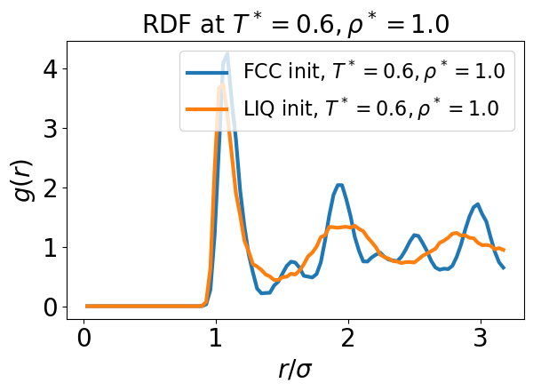

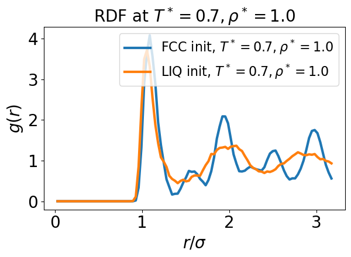

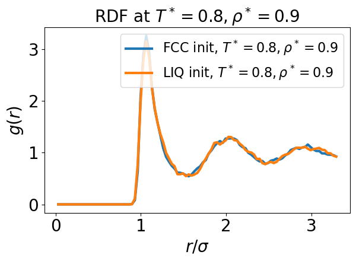

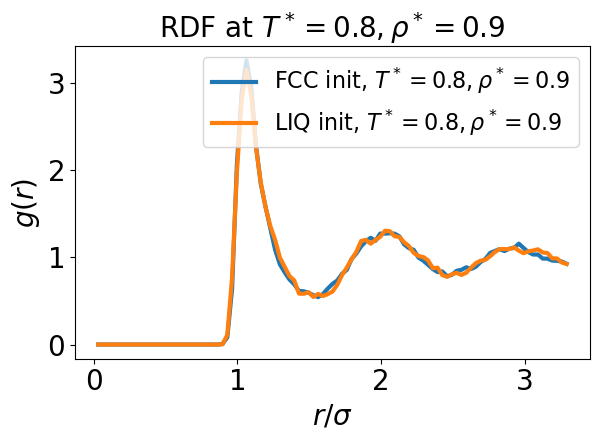

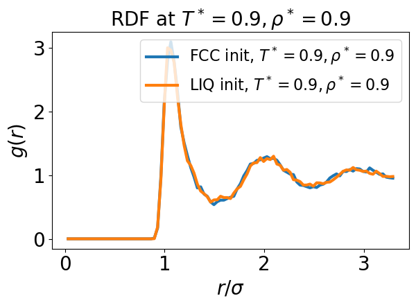

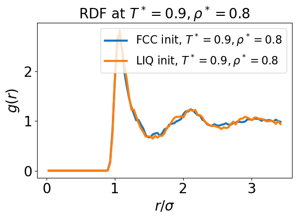

```python
# 4-4 (cont.) Compute RDF
def compute_rdf(positions, L, Nbins=100, r_max=None):
    N = len(positions[0])
    dr = L / (2 * Nbins) if r_max is None else r_max / Nbins
    rdf = np.zeros(Nbins)
    r_vals = np.linspace(0, Nbins * dr, Nbins)
    norm = 0
    for config in positions:
        for i in range(N):
            for j in range(i + 1, N):
                dx = config[i] - config[j]
                dx -= L * np.round(dx / L)
                r = np.linalg.norm(dx)
                if r < Nbins * dr:
                    bin_index = int(r / dr)
                    rdf[bin_index] += 2
        norm += 1

    # Normalize
    rho = N / (L ** 3)
    shell_vol = 4 * np.pi * r_vals**2 * dr
    ideal_gas = rho * shell_vol * N * norm
    rdf /= ideal_gas
    return r_vals, rdf

statepoints = [
    (0.6, 1.0),
    (0.7, 1.0),
    (0.8, 0.9),
    (0.8, 0.9),
    (0.9, 0.9),
    (0.9, 0.8)
]

# Plot RDF for each statepoint
for T, rho in statepoints:
    for init in ["fcc", "liq"]:
        filename = f"{init}_T_{T}_rho_{rho}.npz"
        times, positions, velocities = SoftSphereSystem.load_simulation_data(filename)
        L = (len(positions[0]) / rho) ** (1/3)
        r_vals, g_r = compute_rdf(positions[-20:], L)

        plt.plot(r_vals, g_r, label=f"{init.upper()} init, $T^*={T}, \\rho^*={rho}$")

    plt.xlabel(r"$r/\sigma$")
    plt.ylabel(r"$g(r)$")
    plt.title(f"RDF at $T^*={T}, \\rho^*={rho}$")
    plt.legend()
    plt.tight_layout()
    plt.show()
```

```
Loading: fcc_T_0.6_rho_1.0.npz
```

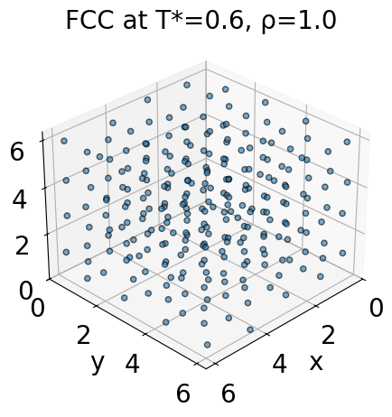

```
Loading: liq_T_0.6_rho_1.0.npz
```

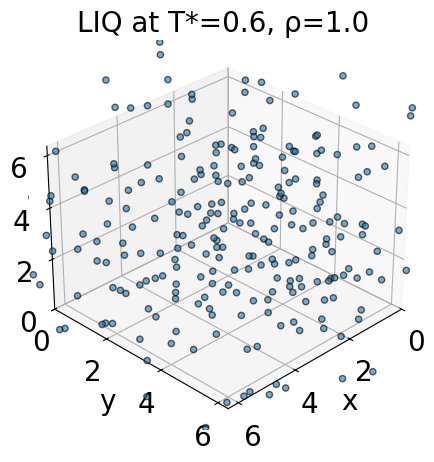

```
Loading: fcc_T_0.7_rho_1.0.npz
```

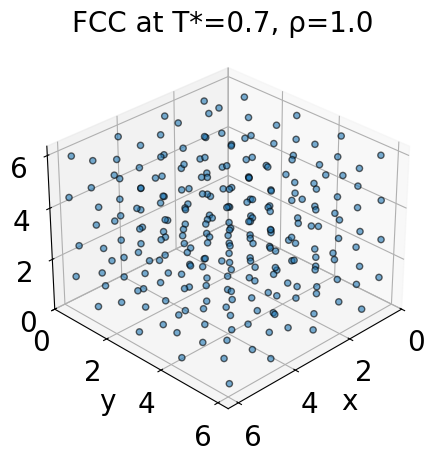

```
Loading: liq_T_0.7_rho_1.0.npz
```

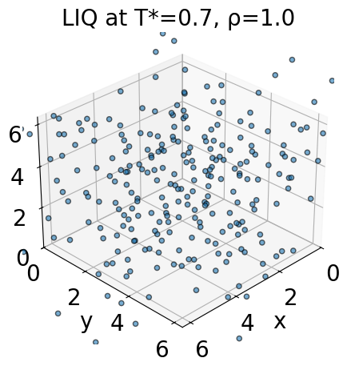

```
Loading: fcc_T_0.8_rho_0.9.npz
```

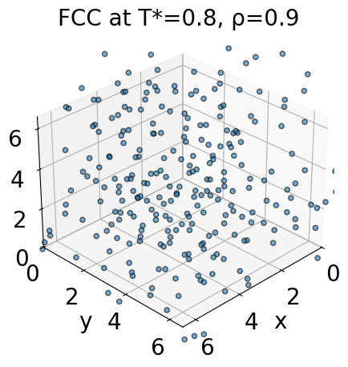

```
Loading: liq_T_0.8_rho_0.9.npz
```

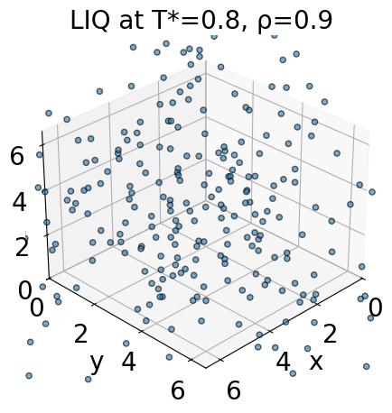

```
Loading: fcc_T_0.8_rho_0.9.npz
```

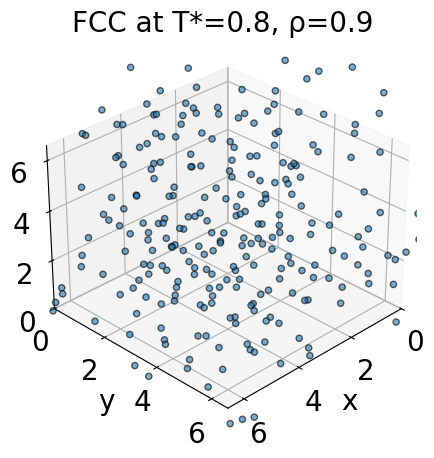

```
Loading: liq_T_0.8_rho_0.9.npz
```

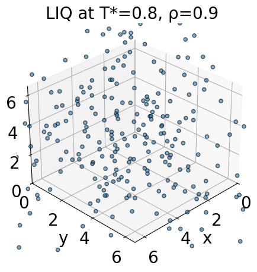

```
Loading: fcc_T_0.9_rho_0.9.npz
```

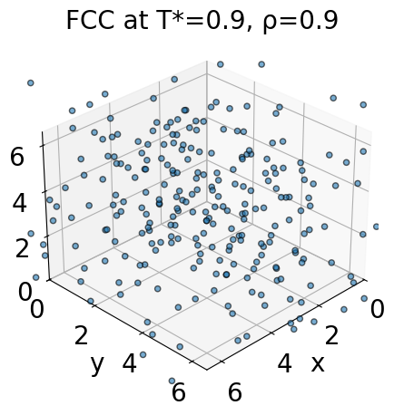

```
Loading: liq_T_0.9_rho_0.9.npz
```

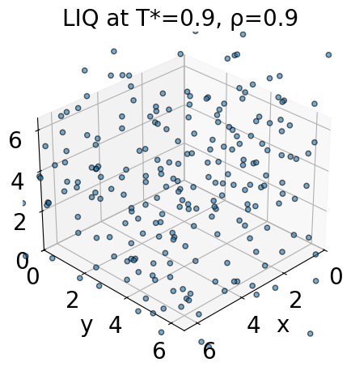

```
Loading: fcc_T_0.9_rho_0.8.npz
```

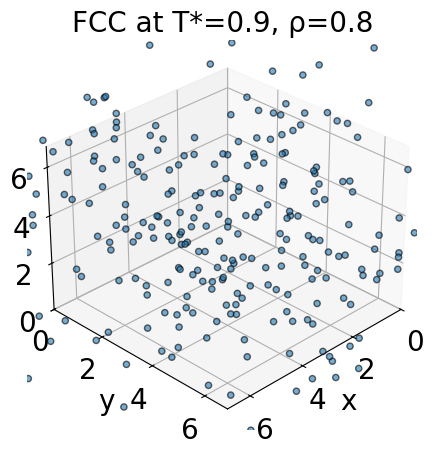

```
Loading: liq_T_0.9_rho_0.8.npz
```

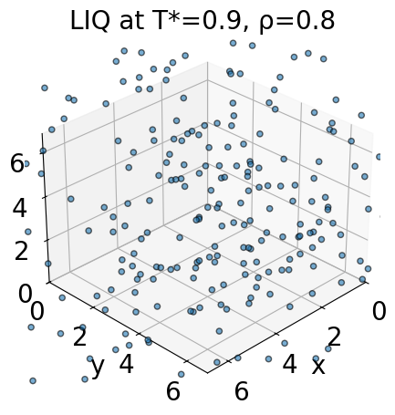

```python
import matplotlib.pyplot as plt
from mpl_toolkits.mplot3d import Axes3D

statepoints = [
    (0.6, 1.0),
    (0.7, 1.0),
    (0.8, 0.9),
    (0.8, 0.9),
    (0.9, 0.9),
    (0.9, 0.8)
]

def draw_config_3d(r, box_length, title="3D Snapshot", save_path=None, point_size=20):
    from mpl_toolkits.mplot3d import Axes3D
    import matplotlib.pyplot as plt

    fig = plt.figure()
    ax = fig.add_subplot(111, projection='3d')
    ax.scatter(r[:, 0], r[:, 1], r[:, 2], s=point_size, alpha=0.6, edgecolors='k')

    ax.set_xlim(0, box_length)
    ax.set_ylim(0, box_length)
    ax.set_zlim(0, box_length)
    ax.set_xlabel('x')
    ax.set_ylabel('y')
    ax.set_zlabel('z')
    ax.set_title(title)
    ax.view_init(elev=30, azim=45)

    if save_path:
        plt.savefig(save_path)
    else:
        plt.tight_layout()
        plt.show()

# Loop through each statepoint
for T, rho in statepoints:
    for init in ["fcc", "liq"]:
        filename = f"{init}_T_{T}_rho_{rho}.npz"
        print(f"Loading: {filename}")
        times, positions, velocities = SoftSphereSystem.load_simulation_data(filename)

        # Use final frame to visualize structure
        final_frame = positions[-1]
        box_length = (len(final_frame) / rho) ** (1/3)
        title = f"{init.upper()} at T*={T}, ρ={rho}"
        draw_config_3d(final_frame, box_length, title=title, save_path=None)
```

#### 4-5

These results seem consistent with the initialization configurations: Both RDF & PE/N analysis

Outline for using enhanced sampling to determine the solid-liquid boundary of the LJ system:

1. need an observable that distinguishes solid from liquid. Can use Steinhardt’s bond orientational order parameters, MSD, density fluctuations. Can also use radial distribution function (solid has sharp peaks, liquid has smoother peaks. Best for distinguishing bewteen crystalline solids and liquids but for amorphous solids can be a bit ambiguous)
2. choose an enhanced sampling method like
   - umbrella sampling which biases along reaction coordinate using harmonic windows and is useful near coexistence, can be used to get full PES
   - or phase pinning where you bias the system toward two-phase coexistence (solid and liquid in the same box) by forcing the order parameter (Q6) to sit between pure solid and pure liquid values, then extract the chemical potential difference Δ𝜇 between phases from the system’s response to the bias
3. construct a bias potential over the order parameter

$ U_{\text{bias}}(Q) = \frac{\kappa}{2} (Q - Q_{\text{ref}})^2 $ which modifies the system's free energy surface: $$ G'(Q) = G(Q) + U_{\text{bias}}(Q) = G(Q) + \frac{\kappa}{2}(Q - Q_{\text{ref}})^2 $$ And the difference in chemical potential between solid and liquid is $$\Delta \mu = -\frac{N \kappa}{\Delta Q} \left( \langle Q \rangle - Q_{\text{ref}} \right)$$ At coexistence the chemical potential is 0, expected value of Q = Qref (reference value between solid and liquid phases)

4. Simulations across a range of T and ρ*: Fix density and scan across temperature. At each T*, run biased simulations to sample transitions between solid and liquid basins and collect histograms or free energy profiles
5. Identify the melting temperature at fixed ρ. The solid-liquid transition point is where F(Q) has two equal-depth basins, or where integrated areas under solid vs. liquid peaks are equal
6. Fix desnity and repeat 4 and 5
7. Use polynomial to fit a melting curve

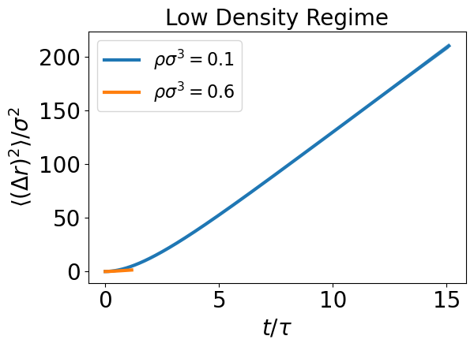

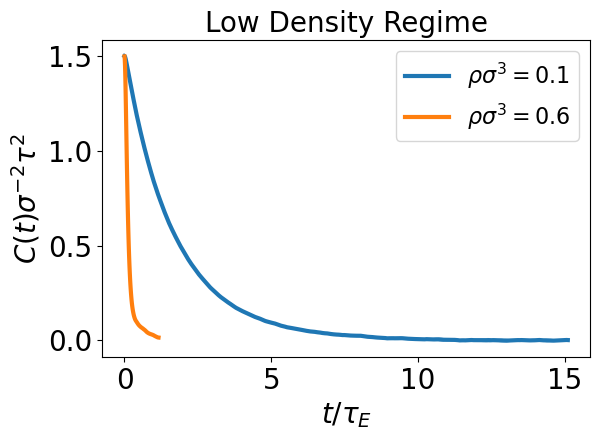

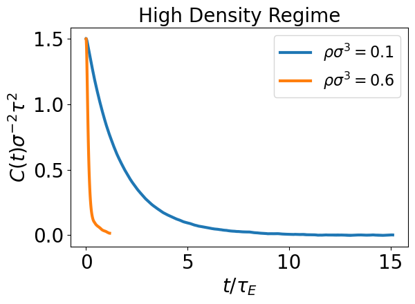

```python
# 4-6 Density effects on diffusion. Calculate diffusion coefficient of LJ fluid using 1) mean squared displacement (MSD) and 2) velocity autocorrelation function (VACF)

# 1) MSD

# We can use Enskog theory to predict relevant time scales
def gr_contact(rho):
    # Contact value of the radial distribution function from Percus-Yevick theory
    eta = np.pi * rho / 6
    return (1 + eta / 2.) / (1 - eta) ** 2

def enskog_relaxation_time(rho, temperature):
    # Enskog relaxation time in LJ time units
    return (np.pi * temperature) ** (-0.5) * (3. / 8.) * (1. / (gr_contact(rho)*rho))

def enskog_diffusion_coefficient(rho, temperature):
    # Enskog diffusion coefficient in LJ units
    return temperature * enskog_relaxation_time(rho, temperature)
densities = np.array( [0.1, 0.6] )
# 20 times the estimated relaxation time should be more than sufficient to get to the long time limit
final_times = np.array( [20 * enskog_relaxation_time(rho, temperature) for rho in densities] )

# Run five trials at each density
numTrials = 5
t_val = 2.228 # t-value for 95% confidence interval
mean_square_displacements = {}
all_times = {}
for rho, final_time in zip(densities, final_times):
    msd = []
    for i in range(numTrials):
        system = SoftSphereSystem(nx, rho, temperature, dt, Nsamp, M, include_rescale=False)
        system.run_simulation(rescale_time, final_time, "msd_rho_%.1f_%d.npz" % (rho, i) )
        times, positions, velocities = SoftSphereSystem.load_simulation_data("msd_rho_%.1f_%d.npz" % (rho, i))
        msd_trial = SoftSphereSystem.compute_mean_square_displacement(final_time / 2, positions, dt * Nsamp, final_time / 20)
        np.savez("msdavg_rho_%.1f_%d.npz" % (rho, i), times=times, msd=msd_trial)
        msd_trial = np.load("msdavg_rho_%.1f_%d.npz" % (rho, i))['msd']
        msd.append(msd_trial)
        #print(i)
    mean_square_displacements[rho] = msd
    all_times[rho] = times[:len(msd[0])] #/ enskog_relaxation_time(rho, temperature) # Could normalize times if you want

# Plot mean square displacements
for rho in densities:
    mean_mean = np.mean(mean_square_displacements[rho], axis=0)
    mean_std_err = np.std(mean_square_displacements[rho], axis=0, ddof=1) / (numTrials ** 0.5)
    plt.plot(all_times[rho], mean_mean, label=r"$\rho\sigma^{3}= %.1f$" % rho)
    plt.fill_between(all_times[rho], mean_mean - t_val * mean_std_err, mean_mean + t_val * mean_std_err, alpha=0.5)
plt.xlabel(r"$t/\tau$")
plt.ylabel(r"$\langle (\Delta r)^2 \rangle/\sigma^{2}$")
plt.title("Low Density Regime")
plt.legend()
plt.tight_layout()
plt.show()



# 2) VACF

velocity_corr_time_series = {}
for rho, final_time in zip(densities, final_times):
    velocity_corr_time_series[rho] = []
    for i in range(numTrials):
        times, positions, velocities = SoftSphereSystem.load_simulation_data("msd_rho_%.1f_%d.npz" % (rho, i))
        corr = SoftSphereSystem.compute_velocity_autocorrelation(final_time / 2, velocities, dt * Nsamp, final_time / 20)
        np.savez("velocity_corr_rho_%.1f_%d.npz" % (rho, i), times=times, corr=corr)
        corr = np.load("velocity_corr_rho_%.1f_%d.npz" % (rho, i))['corr']
        velocity_corr_time_series[rho].append(corr)
        #print(i)

# Plot velocity autocorrelation
for rho in densities:
    mean_corr = np.mean(velocity_corr_time_series[rho], axis=0)
    mean_std_err = np.std(velocity_corr_time_series[rho], axis=0, ddof=1) / (numTrials ** 0.5)
    plt.plot(all_times[rho], mean_corr, label=r"$\rho\sigma^{3}= %.1f$" % rho)
    plt.fill_between(all_times[rho], mean_corr - t_val * mean_std_err, mean_corr + t_val * mean_std_err, alpha=0.5)
plt.xlabel(r"$t/\tau_E$")
plt.ylabel(r"$C(t)\sigma^{-2}\tau^{2}$")
plt.title("Low Density Regime")
plt.legend()
plt.tight_layout()
plt.show()

for rho in densities:
    mean_corr = np.mean(velocity_corr_time_series[rho], axis=0)
    mean_std_err = np.std(velocity_corr_time_series[rho], axis=0, ddof=1) / (numTrials ** 0.5)
    plt.plot(all_times[rho], mean_corr, label=r"$\rho\sigma^{3}= %.1f$" % rho)
    plt.fill_between(all_times[rho], mean_corr - t_val * mean_std_err, mean_corr + t_val * mean_std_err, alpha=0.5)
plt.xlabel(r"$t/\tau_E$")
plt.ylabel(r"$C(t)\sigma^{-2}\tau^{2}$")
plt.title("High Density Regime")
plt.legend()
plt.tight_layout()
plt.show()
```